# 예측방법론 실습

# 준비

`library()` 함수는 기본 `R` 배포에 포함되어 있지 않은 함수랑 데이터셋의 모임인 *library*를 불러낸낸다. 최소 제곱 선형 회귀 및 기타 간단한 분석을 수행하는 기본 함수는 기본 배포에 포함되어 있지만, 더 다양한 함수를 사용하려면 추가 라이브러리가 필요하다. 여기선 이 책과 관련된 데이터셋을 포함하는 ISLR2 패키지를 로드한다.

```r
# library(MASS)
library(ISLR2)
```

이러한 라이브러리를 불러올 때 오류 메시지가 표시되면 해당 라이브러리가 아직 시스템에 설치되지 않아서일 가능성이 높다. `MASS`와 같은 일부 라이브러리는 `R`과 함께 제공되어 컴퓨터에 별도로 설치할 필요가 없다. 그러나 `ISLR2`와 같은 다른 패키지는 처음 사용될 때 다운로드해야 한다. 이는 R 내에서 직접 할 수 있다. 예를 들어 Rstudio 에서는 Packages 탭 아래의 Install package 옵션을 선택한다. 임의의 미러 사이트를 선택하면 사용 가능한 패키지 목록이 표시된다. 원하는 패키지를 선택하면 `R`이 자동으로 패키지를 다운로드한다. 또는 이를 R 명령 줄에서 `install.packages("ISLR2")`를 통해 수행할 수 있다. 이 설치는 패키지를 처음 사용할 때에만 필요하다. 그러나 library() 함수는 각 `R` 세션에서 호출되어야 한다.

# 단순선형회귀, 다중선형회귀

## 단순선형회귀(Simple Linear Regression)

`ISLR2` 라이브러리에는 Boston 데이터셋이 포함되어 있다. 이 데이터셋은 보스턴의 $506$개 인구 조사 구역에서 `medv`(중간 주택 가격)를 기록한다. 우리는 rmvar(집 당 평균 방 수), `age`(1940년 이전에 건설된 주택의 비율) 및 `lstat`(저소득층 비율)와 같은 $12$개의 예측 변수를 사용하여 medv를 예측하려고 한다.

```r
head(Boston)
```

```
##      crim zn indus chas   nox    rm  age    dis rad tax ptratio lstat medv
## 1 0.00632 18  2.31    0 0.538 6.575 65.2 4.0900   1 296    15.3  4.98 24.0
## 2 0.02731  0  7.07    0 0.469 6.421 78.9 4.9671   2 242    17.8  9.14 21.6
## 3 0.02729  0  7.07    0 0.469 7.185 61.1 4.9671   2 242    17.8  4.03 34.7
## 4 0.03237  0  2.18    0 0.458 6.998 45.8 6.0622   3 222    18.7  2.94 33.4
## 5 0.06905  0  2.18    0 0.458 7.147 54.2 6.0622   3 222    18.7  5.33 36.2
## 6 0.02985  0  2.18    0 0.458 6.430 58.7 6.0622   3 222    18.7  5.21 28.7
```

데이터셋을 더 자세히 알아보려면 `?Boston`을 입력하면 된다.

우선 `lm()` 함수를 사용하여 단순 선형 회귀 모델을 적합해 보는데, 여기서 `medv`이 반응변수이고 `lstat`이 예측변수이다. 기본 구문은 `lm(y ~ x, data)`이며,`y`는 반응변수, `x`는 예측변수이고, `data`는 이 두 변수가 포함된 데이터셋이다.

```r
lm.fit <- lm(medv ~ lstat)
```

```
## Error in eval(predvars, data, env): 객체 'medv'를 찾을 수 없습니다
```

이 명령은 `R`이 `medv`와 `lstat` 변수를 어디서 찾을지 모르기 때문에 오류가 발생한다. 다음 명령은 `R`에게 변수가 `Boston`에 있다고 알려준다. `R`에 `Boston`을 첨부(attach)하면 `R`이 이제 변수를 인식하므로 첫 줄도 잘 작동한다.

```r
lm.fit <- lm(medv ~ lstat, data = Boston)
attach(Boston)
lm.fit <- lm(medv ~ lstat)
```

`lm.fit`을 입력하면 모형에 대한 일부 기본 정보가 출력된다. 보다 자세한 정보를 얻으려면 `summary(lm.fit)`를 사용합니다. 이렇게 하면 계수에 대한 $p$-값과 표준 오차, 모형에 대한 $R^2$ 통계 및 $F$-통계를 볼 수 있다.

```r
lm.fit
```

```
##
## Call:
## lm(formula = medv ~ lstat)
##
## Coefficients:
## (Intercept)        lstat
##       34.55        -0.95
```

```r
summary(lm.fit)
```

```
##
## Call:
## lm(formula = medv ~ lstat)
##
## Residuals:
##     Min      1Q  Median      3Q     Max
## -15.168  -3.990  -1.318   2.034  24.500
##
## Coefficients:
##             Estimate Std. Error t value Pr(>|t|)
## (Intercept) 34.55384    0.56263   61.41   <2e-16 ***
## lstat       -0.95005    0.03873  -24.53   <2e-16 ***
## ---
## Signif. codes:  0 '***' 0.001 '**' 0.01 '*' 0.05 '.' 0.1 ' ' 1
##
## Residual standard error: 6.216 on 504 degrees of freedom
## Multiple R-squared:  0.5441, Adjusted R-squared:  0.5432
## F-statistic: 601.6 on 1 and 504 DF,  p-value: < 2.2e-16
```

`lm.fit`에 어떤 정보들이 있는지 보기 위해 `names()` 함수를 사용할 수 있다. 그 정보에 접근하기 위해 `lm.fit$coefficients`와 같은 식으로 이름을 이용하여 추출할 수 있지만, `coef()`와 같은 식으로 추출기 함수를 사용하여 정보를 접근하는 편이 더 안전하다.

```r
names(lm.fit)
```

```
##  [1] "coefficients"  "residuals"     "effects"       "rank"
##  [5] "fitted.values" "assign"        "qr"            "df.residual"
##  [9] "xlevels"       "call"          "terms"         "model"
```

```r
coef(lm.fit)
```

```
## (Intercept)       lstat
##  34.5538409  -0.9500494
```

계수 추정량에 대한 신뢰 구간을 얻기 위해 `confint()` 명령을 사용할 수 있다.

In order to obtain a confidence interval for the coefficient estimates, we can use the `confint()` command.

```r
confint(lm.fit)
```

```
##                 2.5 %     97.5 %
## (Intercept) 33.448457 35.6592247
## lstat       -1.026148 -0.8739505
```

predict() 함수를 사용하여 주어진 `lstat` 값에 대한 `medv` 예측의 신뢰 구간과 예측 구간을 생성할 수 있다.

The `predict()` function can be used to produce confidence intervals and prediction intervals for the prediction of `medv` for a given value of `lstat`.

```r
predict(lm.fit, data.frame(lstat = (c(5, 10, 15))),
    interval = "confidence")
```

```
##        fit      lwr      upr
## 1 29.80359 29.00741 30.59978
## 2 25.05335 24.47413 25.63256
## 3 20.30310 19.73159 20.87461
```

```r
predict(lm.fit, data.frame(lstat = (c(5, 10, 15))),
    interval = "prediction")
```

```
##        fit       lwr      upr
## 1 29.80359 17.565675 42.04151
## 2 25.05335 12.827626 37.27907
## 3 20.30310  8.077742 32.52846
```

예를 들어, `lstat` 값이 10인 경우 95% 신뢰 구간은 $(24.47, 25.63)$이며, 95% 예측 구간은 $(12.828, 37.28)$이다. 기대한 대로, 신뢰 구간과 예측 구간은 동일한 지점(즉, `lstat`가 10일 때 `medv`의 예측 값인 $25.05$)을 중심으로 하지만 예측 구간이 훨씬 넓다.

이제 `plot()` 및 `abline()` 함수를 사용하여 `medv`와 `lstat`을 최소 제곱 회귀선과 함께 그린다.

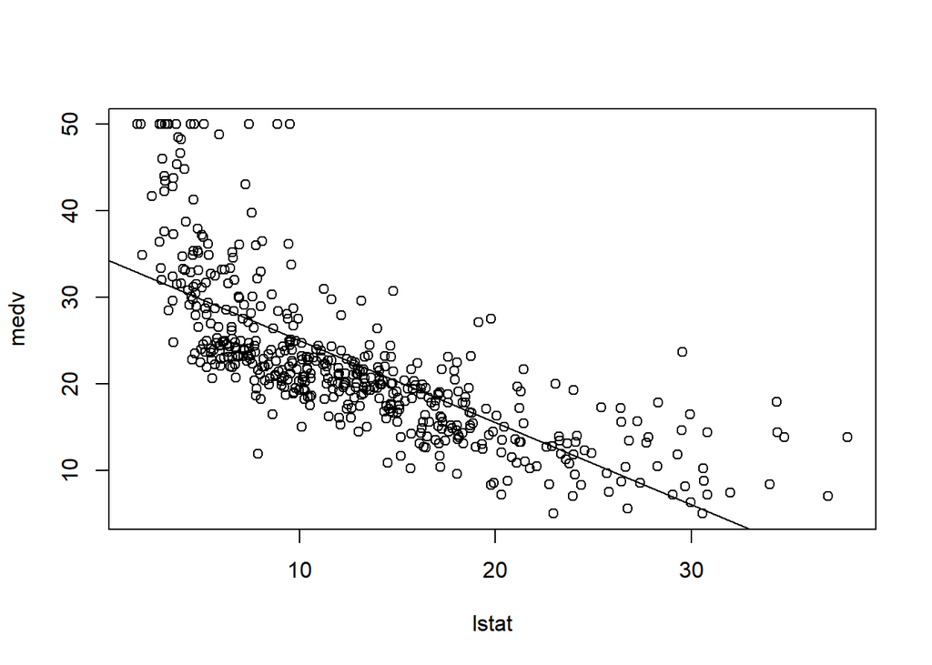

```r
plot(lstat, medv)
abline(lm.fit)
```

lstat와 medv 사이의 관계에 비선형성이 일부 있음을 볼 수 있다. 나중에 이 문제를 다시 볼 것이다.

`abline()` 함수는 최소 제곱 회귀선뿐만 아니라 모든 선을 그리는 데 사용할 수 있다. 절편 a와 기울기 b를 가진 선을 그리려면 abline(a, b)를 입력한다. 아래에서 선 및 점을 그리기 위한 몇 가지 추가 설정을 볼 것이다. `lwd = 3` 명령은 회귀선의 폭을 3배로 증가시킨다. 이는 `plot()` 및 `lines()` 함수에도 적용된다. 점을 찍는 데에 다른 기호를 쓰려면 `pch` 옵션을 사용하면 된다.

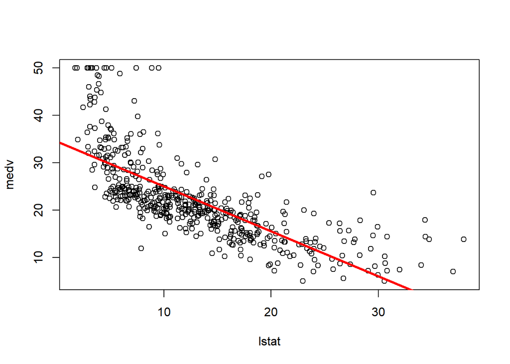

```r
plot(lstat, medv)
abline(lm.fit, lwd = 3)
abline(lm.fit, lwd = 3, col = "red")
```

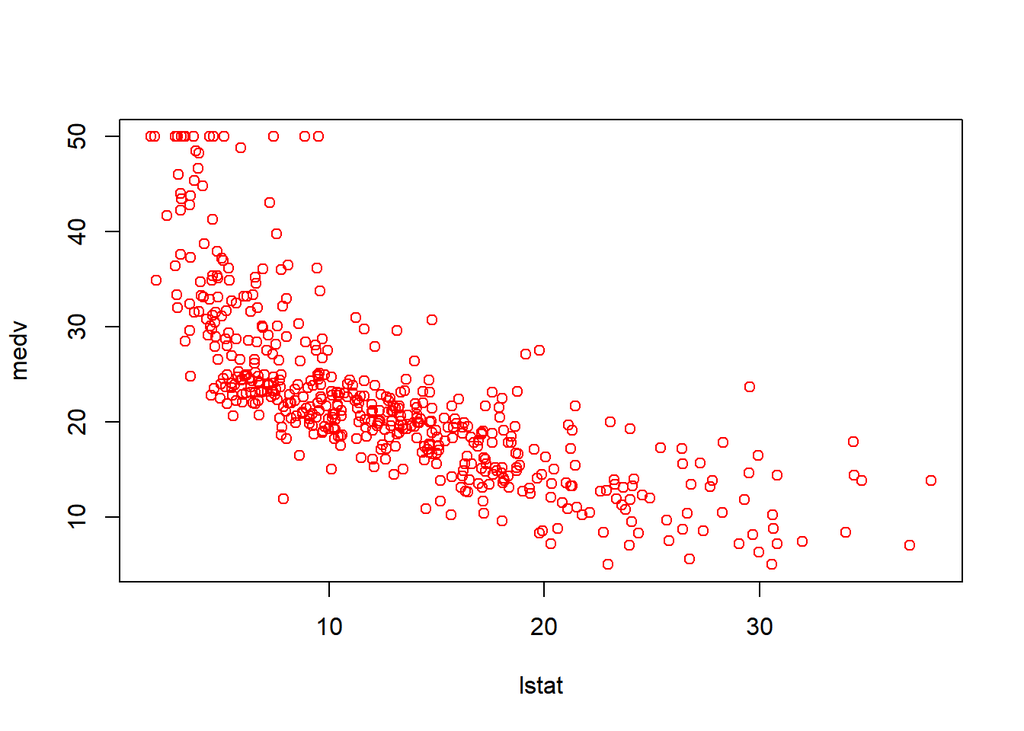

```r
plot(lstat, medv, col = "red")
```

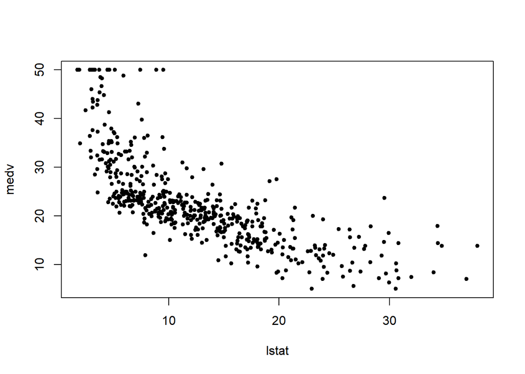

```r
plot(lstat, medv, pch = 20)
```

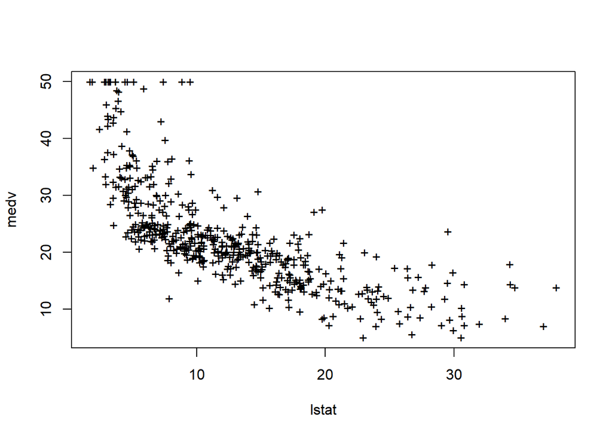

```r
plot(lstat, medv, pch = "+")
```

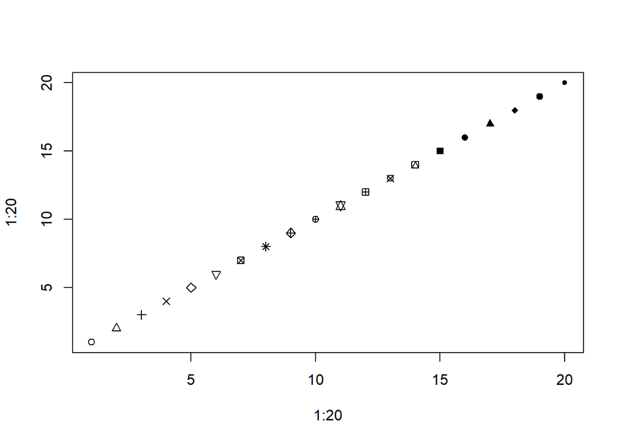

```r
plot(1:20, 1:20, pch = 1:20)
```

## 다중선형회귀(Multiple Linear Regression)

최소 제곱을 사용하여 다중 선형 회귀 모델을 적합하려면 다시 `lm()` 함수를 사용한다. 구문 `lm(y ~ x1 + x2 + x3)`은 세 개의 예측 변수 `x1`, `x2`, 및 `x3`를 사용하여 모형을 적합한다. `summary()` 함수는 모든 예측 변수에 대한 회귀 계수를 출력한다.

```r
lm.fit <- lm(medv ~ lstat + age, data = Boston)
summary(lm.fit)
```

```
##
## Call:
## lm(formula = medv ~ lstat + age, data = Boston)
##
## Residuals:
##     Min      1Q  Median      3Q     Max
## -15.981  -3.978  -1.283   1.968  23.158
##
## Coefficients:
##             Estimate Std. Error t value Pr(>|t|)
## (Intercept) 33.22276    0.73085  45.458  < 2e-16 ***
## lstat       -1.03207    0.04819 -21.416  < 2e-16 ***
## age          0.03454    0.01223   2.826  0.00491 **
## ---
## Signif. codes:  0 '***' 0.001 '**' 0.01 '*' 0.05 '.' 0.1 ' ' 1
##
## Residual standard error: 6.173 on 503 degrees of freedom
## Multiple R-squared:  0.5513, Adjusted R-squared:  0.5495
## F-statistic:   309 on 2 and 503 DF,  p-value: < 2.2e-16
```

`Boston` 데이터셋에는 12개의 변수가 포함되어 있으므로 모든 예측 변수를 사용하여 회귀를 수행하려면 모두 입력하는 것이 번거롭다. 대신 다음 약식을 사용할 수 있습니다:

```r
lm.fit <- lm(medv ~ ., data = Boston)
summary(lm.fit)
```

```
##
## Call:
## lm(formula = medv ~ ., data = Boston)
##
## Residuals:
##      Min       1Q   Median       3Q      Max
## -15.1304  -2.7673  -0.5814   1.9414  26.2526
##
## Coefficients:
##               Estimate Std. Error t value Pr(>|t|)
## (Intercept)  41.617270   4.936039   8.431 3.79e-16 ***
## crim         -0.121389   0.033000  -3.678 0.000261 ***
## zn            0.046963   0.013879   3.384 0.000772 ***
## indus         0.013468   0.062145   0.217 0.828520
## chas          2.839993   0.870007   3.264 0.001173 **
## nox         -18.758022   3.851355  -4.870 1.50e-06 ***
## rm            3.658119   0.420246   8.705  < 2e-16 ***
## age           0.003611   0.013329   0.271 0.786595
## dis          -1.490754   0.201623  -7.394 6.17e-13 ***
## rad           0.289405   0.066908   4.325 1.84e-05 ***
## tax          -0.012682   0.003801  -3.337 0.000912 ***
## ptratio      -0.937533   0.132206  -7.091 4.63e-12 ***
## lstat        -0.552019   0.050659 -10.897  < 2e-16 ***
## ---
## Signif. codes:  0 '***' 0.001 '**' 0.01 '*' 0.05 '.' 0.1 ' ' 1
##
## Residual standard error: 4.798 on 493 degrees of freedom
## Multiple R-squared:  0.7343, Adjusted R-squared:  0.7278
## F-statistic: 113.5 on 12 and 493 DF,  p-value: < 2.2e-16
```

요약 객체의 개별 구성 요소에 이름을 사용하여 접근할 수 있다(사용 가능한 내용을 보려면 `?summary.lm`을 입력한다). 따라서 `summary(lm.fit)$r.sq`는 $R^2$를 제공하고 `summary(lm.fit)$sigma`는 RSE를 제공한다.

모든 변수를 사용하지만 하나를 제외한 회귀분석은 어떻게 할까? 예를 들어, 위의 회귀 결과에서 `age`의 $p$-값이 높다. 따라서 이 예측 변수를 제외한 회귀를 하고자 할 수 있다. 다음 구문은 `age`를 제외한 모든 예측 변수를 사용한 회귀분석을 실행한다.

```r
lm.fit1 <- lm(medv ~ . - age, data = Boston)
summary(lm.fit1)
```

```
##
## Call:
## lm(formula = medv ~ . - age, data = Boston)
##
## Residuals:
##      Min       1Q   Median       3Q      Max
## -15.1851  -2.7330  -0.6116   1.8555  26.3838
##
## Coefficients:
##               Estimate Std. Error t value Pr(>|t|)
## (Intercept)  41.525128   4.919684   8.441 3.52e-16 ***
## crim         -0.121426   0.032969  -3.683 0.000256 ***
## zn            0.046512   0.013766   3.379 0.000785 ***
## indus         0.013451   0.062086   0.217 0.828577
## chas          2.852773   0.867912   3.287 0.001085 **
## nox         -18.485070   3.713714  -4.978 8.91e-07 ***
## rm            3.681070   0.411230   8.951  < 2e-16 ***
## dis          -1.506777   0.192570  -7.825 3.12e-14 ***
## rad           0.287940   0.066627   4.322 1.87e-05 ***
## tax          -0.012653   0.003796  -3.333 0.000923 ***
## ptratio      -0.934649   0.131653  -7.099 4.39e-12 ***
## lstat        -0.547409   0.047669 -11.483  < 2e-16 ***
## ---
## Signif. codes:  0 '***' 0.001 '**' 0.01 '*' 0.05 '.' 0.1 ' ' 1
##
## Residual standard error: 4.794 on 494 degrees of freedom
## Multiple R-squared:  0.7343, Adjusted R-squared:  0.7284
## F-statistic: 124.1 on 11 and 494 DF,  p-value: < 2.2e-16
```

대안으로 update() 함수를 사용할 수 있다.

```r
lm.fit1 <- update(lm.fit, ~ . - age)
```

# 가변수(지시변수)

이제 `ISLR2` 라이브러리의 `Carseats` 데이터를 살펴볼 것이다. 여러 예측 변수를 기반으로 $400$개의 위치에서 `Sales`(어린이 카시트 판매)를 예측하려고 합니다.

```r
head(Carseats)
```

```
##   Sales CompPrice Income Advertising Population Price ShelveLoc Age Education
## 1  9.50       138     73          11        276   120       Bad  42        17
## 2 11.22       111     48          16        260    83      Good  65        10
## 3 10.06       113     35          10        269    80    Medium  59        12
## 4  7.40       117    100           4        466    97    Medium  55        14
## 5  4.15       141     64           3        340   128       Bad  38        13
## 6 10.81       124    113          13        501    72       Bad  78        16
##   Urban  US
## 1   Yes Yes
## 2   Yes Yes
## 3   Yes Yes
## 4   Yes Yes
## 5   Yes  No
## 6    No Yes
```

`Carseats` 데이터에는 각 위치의 카시트가 전시된 가게 내부 공간인 shelveloc와 같은 질적 예측 변수가 포함되어 있다. 예측 변수 `shelveloc`는 세 가지 값(*Bad*, *Medium*, *Good*) 중 하나를 가진다. shelveloc와 같은 질적 변수가 주어진 경우 R은 자동으로 가변수(지시 변수, dummy variable)를 생성한다. 아래에서 다중 회귀 모델을 적합한다.

```r
lm.fit <- lm(Sales ~ ., data = Carseats)
summary(lm.fit)
```

```
##
## Call:
## lm(formula = Sales ~ ., data = Carseats)
##
## Residuals:
##     Min      1Q  Median      3Q     Max
## -2.8692 -0.6908  0.0211  0.6636  3.4115
##
## Coefficients:
##                   Estimate Std. Error t value Pr(>|t|)
## (Intercept)      5.6606231  0.6034487   9.380  < 2e-16 ***
## CompPrice        0.0928153  0.0041477  22.378  < 2e-16 ***
## Income           0.0158028  0.0018451   8.565 2.58e-16 ***
## Advertising      0.1230951  0.0111237  11.066  < 2e-16 ***
## Population       0.0002079  0.0003705   0.561    0.575
## Price           -0.0953579  0.0026711 -35.700  < 2e-16 ***
## ShelveLocGood    4.8501827  0.1531100  31.678  < 2e-16 ***
## ShelveLocMedium  1.9567148  0.1261056  15.516  < 2e-16 ***
## Age             -0.0460452  0.0031817 -14.472  < 2e-16 ***
## Education       -0.0211018  0.0197205  -1.070    0.285
## UrbanYes         0.1228864  0.1129761   1.088    0.277
## USYes           -0.1840928  0.1498423  -1.229    0.220
## ---
## Signif. codes:  0 '***' 0.001 '**' 0.01 '*' 0.05 '.' 0.1 ' ' 1
##
## Residual standard error: 1.019 on 388 degrees of freedom
## Multiple R-squared:  0.8734, Adjusted R-squared:  0.8698
## F-statistic: 243.4 on 11 and 388 DF,  p-value: < 2.2e-16
```

`contrasts()` 함수는 `R`이 가변수에 사용하는 코딩을 반환한다.

```r
attach(Carseats)
contrasts(ShelveLoc)
```

```
##        Good Medium
## Bad       0      0
## Good      1      0
## Medium    0      1
```

다른 대조 방법 및 설정 방법에 대해 알아보려면 `?contrasts`를 사용하면 된다.

`R`은 `ShelveLocGood` 가변수를 생성했다. 이 변수는 전시 위치가 좋으면 값이 1이고 그렇지 않으면 0입니다. 또한 `ShelveLocMedium` 가가변수를 생성했으며, 이 변수는 전시 위치가 중간이면 값이 1이고 그렇지 않으면 0이다. 나쁜 전시 위치는 두 가변수 각각에 대해 0에 해당합니다. 회귀 결과에서 `ShelveLocGood`에 대한 계수가 양수이므로 좋은 전시 위치가 높은 판매와 관련이 있음을 나타낸다(나쁜 위치에 비해). 그리고 `ShelveLocMedium`는 상대적으로 작은 양수 계수를 갖고 있으며, 이는 중간 전시 위치가 나쁜 전시 위치보다 높은 판매와 관련이 있지만 좋은 전시 위치보다는 낮은 판매와 관련이 있다는 것을 나타낸다.

# 모형진단

다음으로 일부 진단 플롯을 살펴볼 것이다. `lm()`에서 출력된 결과에 직접 `plot()` 함수를 적용하여 자동으로 생성되는 진단 플롯이 네 개 있습니다. 일반적으로 이 명령은 한 번에 한 개의 플롯을 생성하며, *Enter*를 누르면 다음 플롯이 생성된다. 그러나 종종 네 개의 플롯을 모두 함께 보는 것이 편리하다. 이를 위해 `par()` 및 `mfrow()` 함수를 사용하여 `R`에게 화면을 여러 패널로 나누어 여러 플롯을 동시에 볼 수 있도록 지시할 수 있다. 예를 들어, `par(mfrow = c(2, 2))`는 화면을 $2 \times 2$ 격자로 나눕니다.

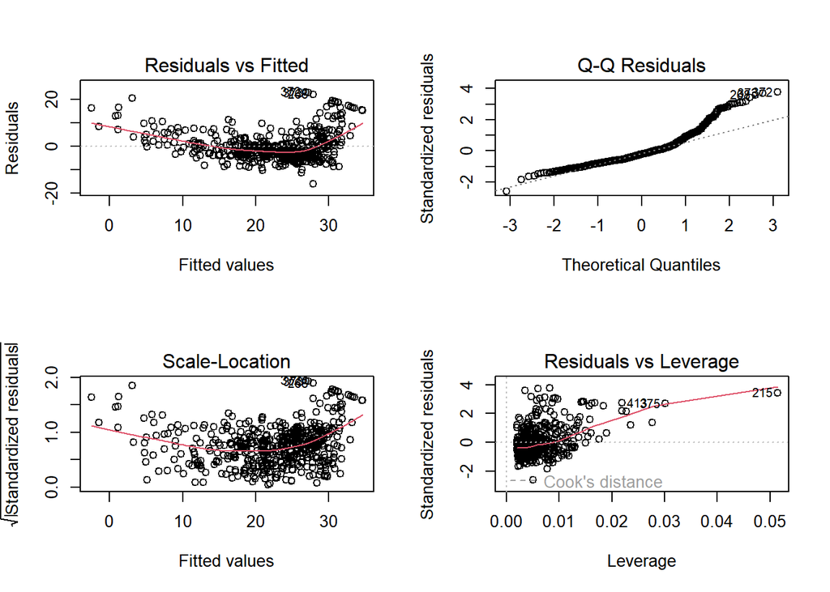

```r
par(mfrow = c(2, 2))
lm.fit <- lm(medv ~ lstat + age, data = Boston)
plot(lm.fit)
```

대안으로, `residuals()` 함수를 사용하여 선형 회귀 적합에서 잔차를 계산할 수 있다. 함수 `rstudent()`는 studentized 잔차를 반환하며, 이 함수를 사용하여 잔차와 적합된 값을 플롯할 수 있습니다.

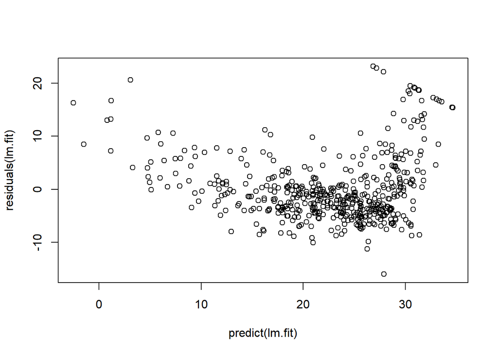

```r
plot(predict(lm.fit), residuals(lm.fit))
```

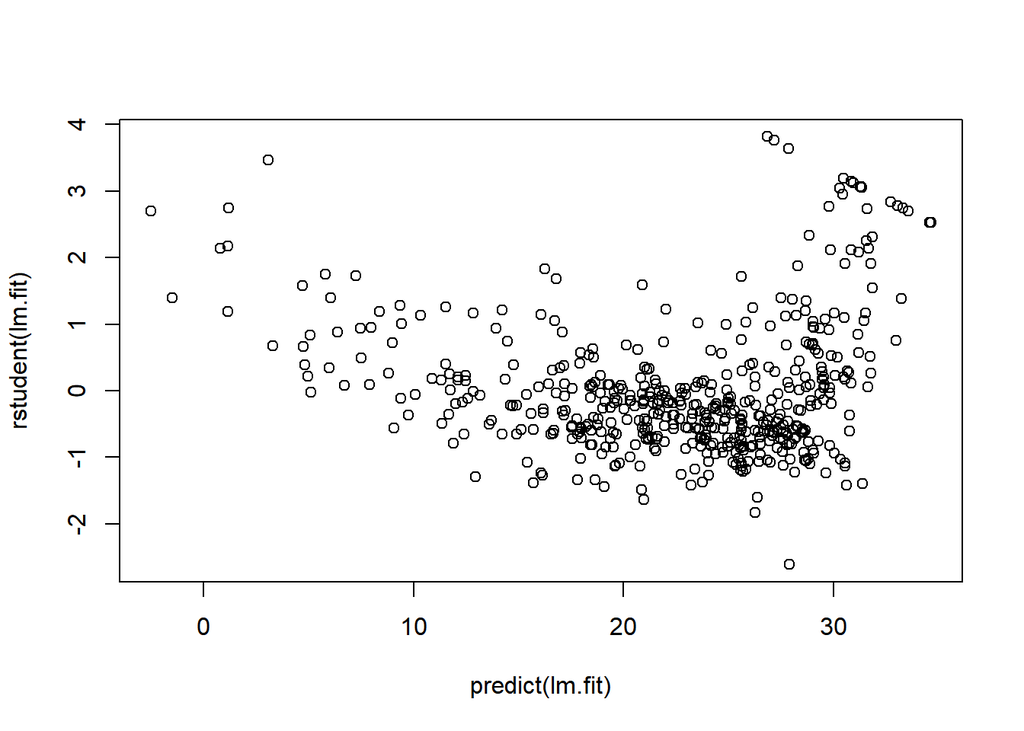

```r
plot(predict(lm.fit), rstudent(lm.fit))
```

잔차 플롯을 기반으로 보면, 비선형성이 나타난다. `hatvalues()` 함수를 사용하여 여러 예측 변수에 대한 레버리지 통계량을 계산할 수 있다.

On the basis of the residual plots, there is some evidence of non-linearity. Leverage statistics can be computed for any number of predictors using the `hatvalues()` function.

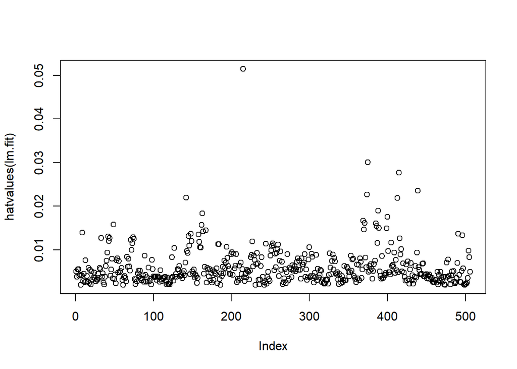

```r
plot(hatvalues(lm.fit))
```

```r
which.max(hatvalues(lm.fit))
```

```
## 215
## 215
```

`which.max()` 함수는 벡터의 가장 큰 요소의 인덱스를 식별한다. 이 경우 가장 큰 레버리지 통계량을 갖는 관측치를 알려줍니다.

# 변수 선택, 능선회귀, 라쏘

## 변수 선택

### 최적부분집합선택(Best Subset Selection)

여기서는 `Hitters` 데이터에 최적부분집합선택(Best Subset Selection) 접근 방식을 적용합니다. 이 데이터에선 지난 해의 성적과 관련된 다양한 통계를 바탕으로 야구 선수의 Salary(연봉)를 예측하려고 한다.

먼저 `Salary` 변수가 일부 선수에게 누락되었다는 것을 볼 수 있다. 누락된 관측값을 식별하는 데 `is.na()` 함수를 사용할 수 있습니다. 이 함수는 입력 벡터와 동일한 길이의 벡터를 반환하며 누락된 요소가 있는 경우 `TRUE`를 반환하고 그렇지 않으면 `FALSE`를 반환합니다. 그런 다음 `sum()` 함수를 사용하여 누락된 데이터의 수를 계산할 수 있다.

```r
library(ISLR2)
names(Hitters)
```

```
##  [1] "AtBat"     "Hits"      "HmRun"     "Runs"      "RBI"       "Walks"
##  [7] "Years"     "CAtBat"    "CHits"     "CHmRun"    "CRuns"     "CRBI"
## [13] "CWalks"    "League"    "Division"  "PutOuts"   "Assists"   "Errors"
## [19] "Salary"    "NewLeague"
```

```r
dim(Hitters)
```

```
## [1] 322  20
```

```r
sum(is.na(Hitters$Salary))
```

```
## [1] 59
```

따라서 `Salary`가 $59$명의 선수에게 누락되었음을 알 수 있다. `na.omit()` 함수는 모든 변수에 누락된 값이 있는 행을 제거한다.

```r
Hitters <- na.omit(Hitters)
dim(Hitters)
```

```
## [1] 263  20
```

```r
sum(is.na(Hitters))
```

```
## [1] 0
```

`regsubsets()` 함수(`leaps` 라이브러리의 일부)는 RSS를 사용하여 주어진 예측 변수의 개수를 포함하는 최상의 모델을 식별하여 최적부분집합선택(Best Subset Selection)을 수행한다. 구문은 `lm()`과 동일하다.`summary()` 명령은 각 모델 크기에 대한 최적의 변수 집합을 출력한다.

```r
library(leaps)
regfit.full <- regsubsets(Salary ~ ., Hitters)
summary(regfit.full)
```

```
## Subset selection object
## Call: regsubsets.formula(Salary ~ ., Hitters)
## 19 Variables  (and intercept)
##            Forced in Forced out
## AtBat          FALSE      FALSE
## Hits           FALSE      FALSE
## HmRun          FALSE      FALSE
## Runs           FALSE      FALSE
## RBI            FALSE      FALSE
## Walks          FALSE      FALSE
## Years          FALSE      FALSE
## CAtBat         FALSE      FALSE
## CHits          FALSE      FALSE
## CHmRun         FALSE      FALSE
## CRuns          FALSE      FALSE
## CRBI           FALSE      FALSE
## CWalks         FALSE      FALSE
## LeagueN        FALSE      FALSE
## DivisionW      FALSE      FALSE
## PutOuts        FALSE      FALSE
## Assists        FALSE      FALSE
## Errors         FALSE      FALSE
## NewLeagueN     FALSE      FALSE
## 1 subsets of each size up to 8
## Selection Algorithm: exhaustive
##          AtBat Hits HmRun Runs RBI Walks Years CAtBat CHits CHmRun CRuns CRBI
## 1  ( 1 ) " "   " "  " "   " "  " " " "   " "   " "    " "   " "    " "   "*"
## 2  ( 1 ) " "   "*"  " "   " "  " " " "   " "   " "    " "   " "    " "   "*"
## 3  ( 1 ) " "   "*"  " "   " "  " " " "   " "   " "    " "   " "    " "   "*"
## 4  ( 1 ) " "   "*"  " "   " "  " " " "   " "   " "    " "   " "    " "   "*"
## 5  ( 1 ) "*"   "*"  " "   " "  " " " "   " "   " "    " "   " "    " "   "*"
## 6  ( 1 ) "*"   "*"  " "   " "  " " "*"   " "   " "    " "   " "    " "   "*"
## 7  ( 1 ) " "   "*"  " "   " "  " " "*"   " "   "*"    "*"   "*"    " "   " "
## 8  ( 1 ) "*"   "*"  " "   " "  " " "*"   " "   " "    " "   "*"    "*"   " "
##          CWalks LeagueN DivisionW PutOuts Assists Errors NewLeagueN
## 1  ( 1 ) " "    " "     " "       " "     " "     " "    " "
## 2  ( 1 ) " "    " "     " "       " "     " "     " "    " "
## 3  ( 1 ) " "    " "     " "       "*"     " "     " "    " "
## 4  ( 1 ) " "    " "     "*"       "*"     " "     " "    " "
## 5  ( 1 ) " "    " "     "*"       "*"     " "     " "    " "
## 6  ( 1 ) " "    " "     "*"       "*"     " "     " "    " "
## 7  ( 1 ) " "    " "     "*"       "*"     " "     " "    " "
## 8  ( 1 ) "*"    " "     "*"       "*"     " "     " "    " "
```

별표(*)는 해당 모델에 특정 변수가 포함되어 있음을 나타낸다. 예를 들어, 이 출력에서 최상의 두 변수 모델에는 `Hits`와 `CRBI`만 포함되어 있음을 나타낸다. 기본적으로 `regsubsets()`는 최상의 여덟 변수 모형까지만 결과를 보고한다. 그러나 `nvmax` 옵션을 사용하여 원하는 개수의 변수 모형을 찾을 수 있다. 여기서는 19개 변수 모형형까지 맞춘다.

```r
regfit.full <- regsubsets(Salary ~ ., data = Hitters,
    nvmax = 19)
reg.summary <- summary(regfit.full)
```

`summary()` 함수는 $R^2$, RSS, 조정된 $R^2$, $C_p$, BIC를 반환한다. 이를 통해 *최상*의 모형을 선택할 수 있다.

```r
names(reg.summary)
```

```
## [1] "which"  "rsq"    "rss"    "adjr2"  "cp"     "bic"    "outmat" "obj"
```

예를 들어, 모형에 하나의 변수만 포함된 경우 $R^2$ 통계치는 $32 \%$이고, 모든 변수가 포함된 경우 $55 \%$에 가까워진다. 예상대로 $R^2$ 통계치는 변수가 더 포함될수록 단조롭게 증가합니다.

```r
reg.summary$rsq
```

```
##  [1] 0.3214501 0.4252237 0.4514294 0.4754067 0.4908036 0.5087146 0.5141227
##  [8] 0.5285569 0.5346124 0.5404950 0.5426153 0.5436302 0.5444570 0.5452164
## [15] 0.5454692 0.5457656 0.5459518 0.5460945 0.5461159
```

RSS, 조정된 $R^2$, $C_p$, BIC를 동시에 모든 모형에 대해 플롯하면 어떤 모형을 선택할지 결정하는 데 도움이 됩니다. `type = "l"` 옵션은 `R`에 플로팅된 점을 선으로 연결하도록 지시한다.

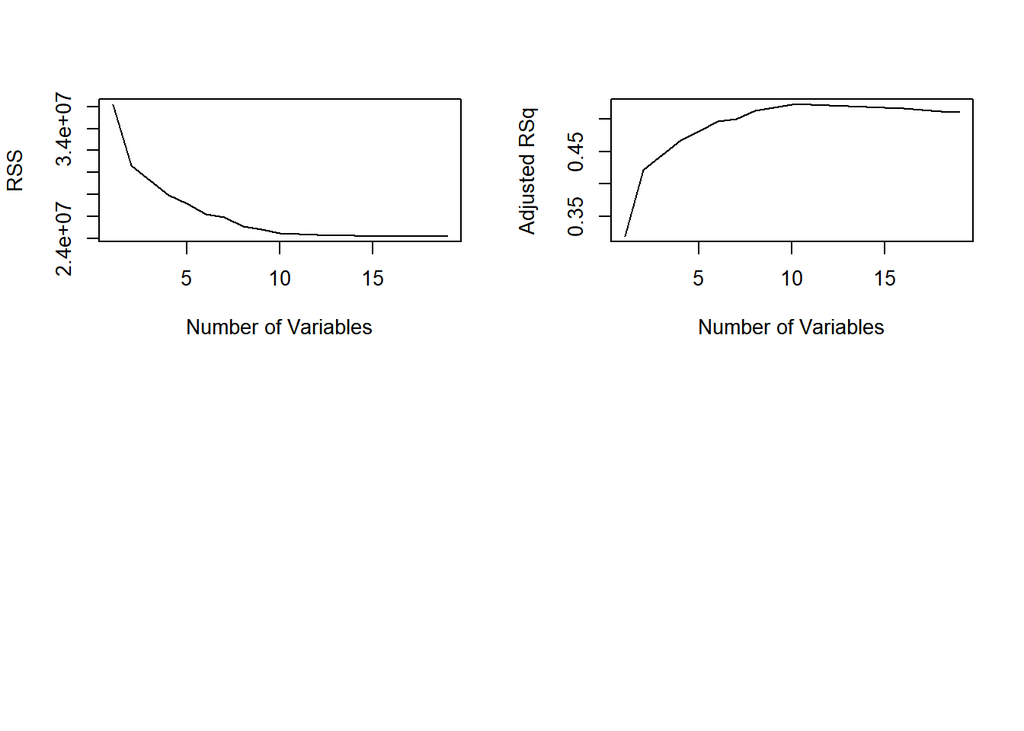

```r
par(mfrow = c(2, 2))
plot(reg.summary$rss, xlab = "Number of Variables",
    ylab = "RSS", type = "l")
plot(reg.summary$adjr2, xlab = "Number of Variables",
    ylab = "Adjusted RSq", type = "l")
```

`points()` 명령은 `plot()` 명령과 유사하지만 새로운 플롯을 생성하는 대신 이미 생성된 플롯에 점을 찍는다. `which.max()` 함수는 벡터의 최대 지점의 위치를 식별하는 데 사용할 수 있습니다. 이제 조정된 $R^2$ 통계치가 가장 큰 모델을 나타내기 위해 빨간 점을 플롯한다.

```r
which.max(reg.summary$adjr2)
```

```
## [1] 11
```

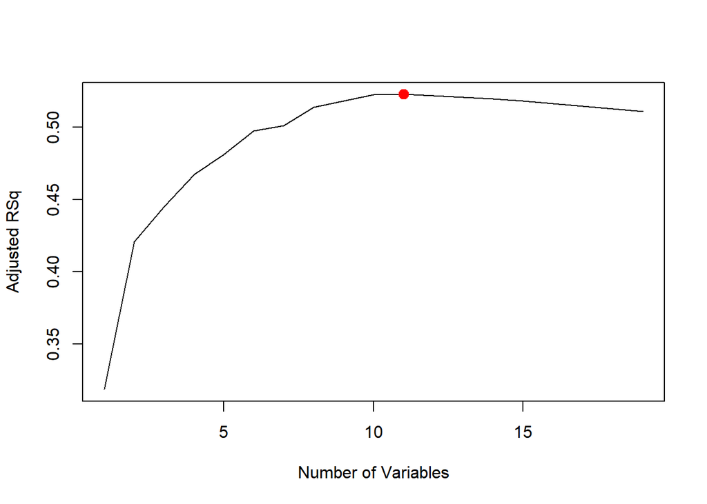

```r
plot(reg.summary$adjr2, xlab = "Number of Variables",
    ylab = "Adjusted RSq", type = "l")
points(11, reg.summary$adjr2[11], col = "red", cex = 2,
    pch = 20)
```

유사한 방식으로 $C_p$ 및 BIC 통계를 플롯하고 which.min()을 사용하여 가장 작은 통계를 갖는 모델을 나타낼 수 있다.

```r
plot(reg.summary$cp, xlab = "Number of Variables",
    ylab = "Cp", type = "l")
which.min(reg.summary$cp)
```

```
## [1] 10
```

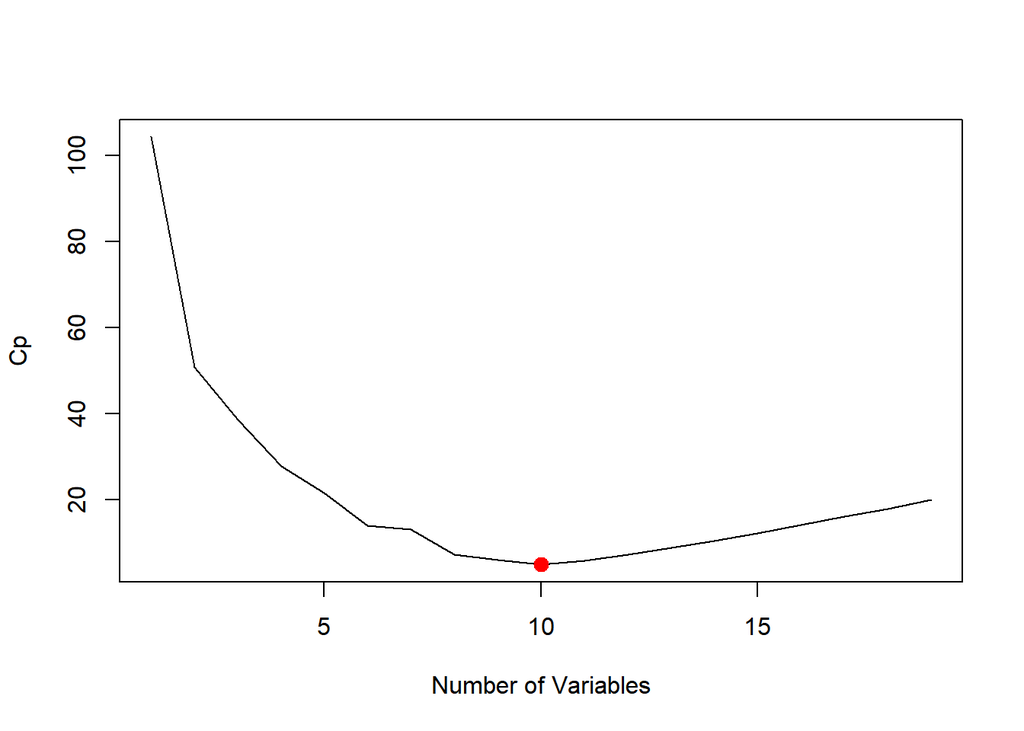

```r
points(10, reg.summary$cp[10], col = "red", cex = 2,
    pch = 20)
```

```r
which.min(reg.summary$bic)
```

```
## [1] 6
```

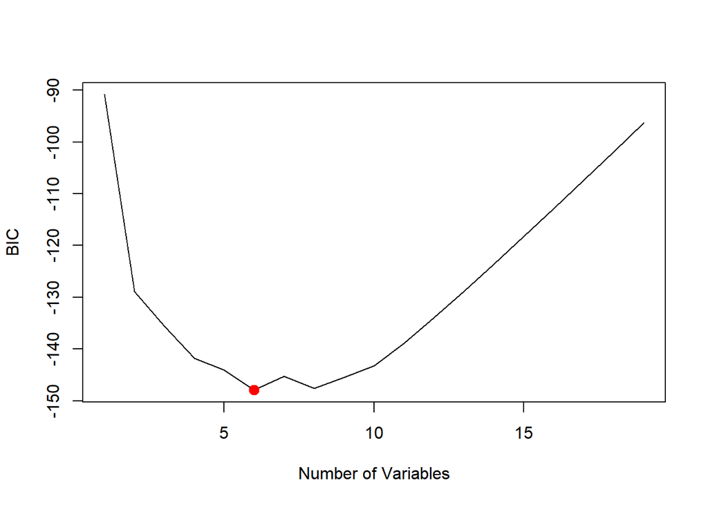

```r
plot(reg.summary$bic, xlab = "Number of Variables",
    ylab = "BIC", type = "l")
points(6, reg.summary$bic[6], col = "red", cex = 2,
    pch = 20)
```

`regsubsets()` 함수에는 BIC, $C_p$, 조정된 $R^2$, 또는 AIC에 따라 순위가 매겨진 주어진 예측 변수 수에 대한 최적 모델의 선택된 변수를 표시하는 내장 `plot()` 명령이 있다. 이 함수에 대해 더 알아보려면 `?plot.regsubsets`를 입력하면 된다. .

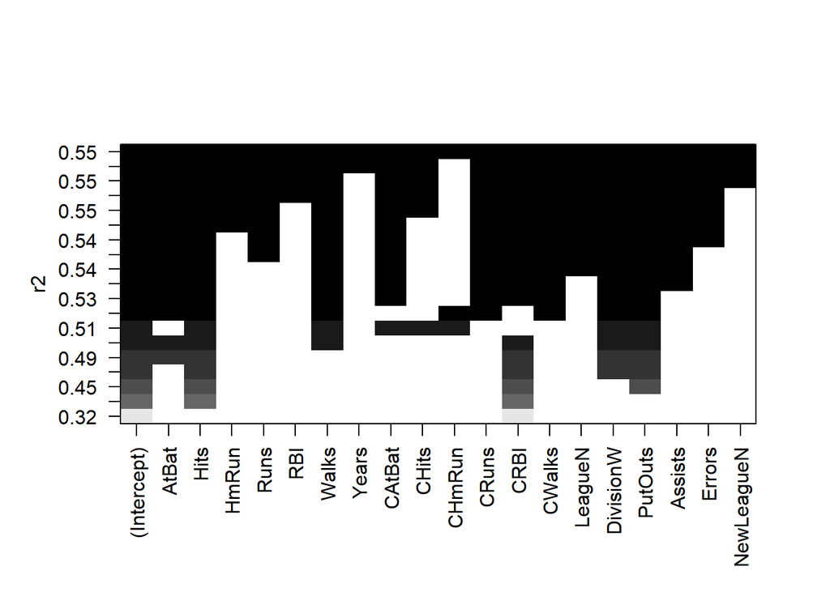

```r
plot(regfit.full, scale = "r2")
```

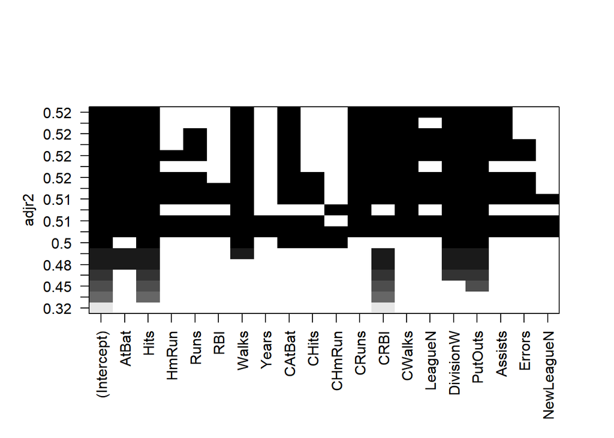

```r
plot(regfit.full, scale = "adjr2")
```

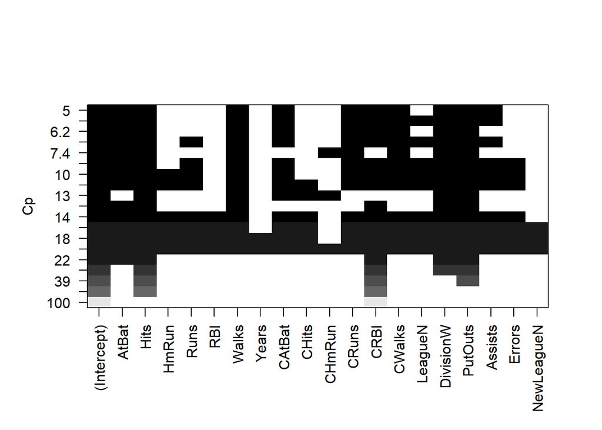

```r
plot(regfit.full, scale = "Cp")
```

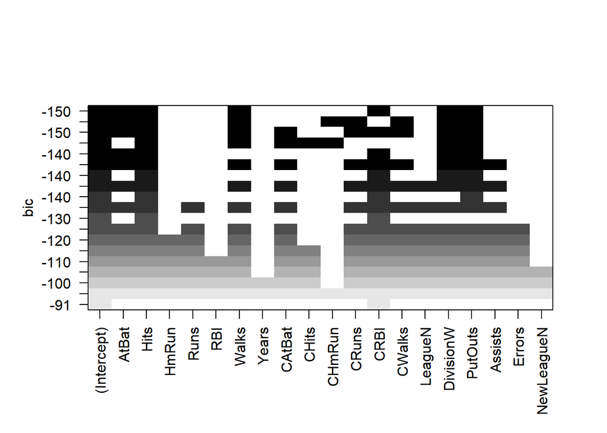

```r
plot(regfit.full, scale = "bic")
```

각 플롯의 맨 위 행에는 해당 통계량과 관련된 최적 모델에 따라 선택된 각 변수에 대한 검정된 검정된 검정된 흑백 정사각형이 있다. 예를 들어, 여러 모델이 BIC가 $-150$에 가까운 것을 볼 수 있다. 그러나 가장 낮은 BIC를 갖는 모델은 `AtBat`, `Hits`, `Walks`, `CRBI`, `DivisionW`, `PutOuts`만 포함하는 6개 변수 모델다. 이 모델과 관련된 계수 추정치를 확인하기 위해 `coef()` 함수를 사용할 수 있다.

```r
coef(regfit.full, 6)
```

```
##  (Intercept)        AtBat         Hits        Walks         CRBI    DivisionW
##   91.5117981   -1.8685892    7.6043976    3.6976468    0.6430169 -122.9515338
##      PutOuts
##    0.2643076
```

### 전진선택법(Forward StepWise Selection)과 후진선택법(Backward Stepwise Selection)

`regsubsets()` 함수를 사용하여 전진 선택법 또는 후진 선택법을 수행할 수 있다. 이는 `method = "forward"` 또는 `method = "backward"` 인수를 사용하여 수행된다.

```r
regfit.fwd <- regsubsets(Salary ~ ., data = Hitters,
    nvmax = 19, method = "forward")
summary(regfit.fwd)
```

```
## Subset selection object
## Call: regsubsets.formula(Salary ~ ., data = Hitters, nvmax = 19, method = "forward")
## 19 Variables  (and intercept)
##            Forced in Forced out
## AtBat          FALSE      FALSE
## Hits           FALSE      FALSE
## HmRun          FALSE      FALSE
## Runs           FALSE      FALSE
## RBI            FALSE      FALSE
## Walks          FALSE      FALSE
## Years          FALSE      FALSE
## CAtBat         FALSE      FALSE
## CHits          FALSE      FALSE
## CHmRun         FALSE      FALSE
## CRuns          FALSE      FALSE
## CRBI           FALSE      FALSE
## CWalks         FALSE      FALSE
## LeagueN        FALSE      FALSE
## DivisionW      FALSE      FALSE
## PutOuts        FALSE      FALSE
## Assists        FALSE      FALSE
## Errors         FALSE      FALSE
## NewLeagueN     FALSE      FALSE
## 1 subsets of each size up to 19
## Selection Algorithm: forward
##           AtBat Hits HmRun Runs RBI Walks Years CAtBat CHits CHmRun CRuns CRBI
## 1  ( 1 )  " "   " "  " "   " "  " " " "   " "   " "    " "   " "    " "   "*"
## 2  ( 1 )  " "   "*"  " "   " "  " " " "   " "   " "    " "   " "    " "   "*"
## 3  ( 1 )  " "   "*"  " "   " "  " " " "   " "   " "    " "   " "    " "   "*"
## 4  ( 1 )  " "   "*"  " "   " "  " " " "   " "   " "    " "   " "    " "   "*"
## 5  ( 1 )  "*"   "*"  " "   " "  " " " "   " "   " "    " "   " "    " "   "*"
## 6  ( 1 )  "*"   "*"  " "   " "  " " "*"   " "   " "    " "   " "    " "   "*"
## 7  ( 1 )  "*"   "*"  " "   " "  " " "*"   " "   " "    " "   " "    " "   "*"
## 8  ( 1 )  "*"   "*"  " "   " "  " " "*"   " "   " "    " "   " "    "*"   "*"
## 9  ( 1 )  "*"   "*"  " "   " "  " " "*"   " "   "*"    " "   " "    "*"   "*"
## 10  ( 1 ) "*"   "*"  " "   " "  " " "*"   " "   "*"    " "   " "    "*"   "*"
## 11  ( 1 ) "*"   "*"  " "   " "  " " "*"   " "   "*"    " "   " "    "*"   "*"
## 12  ( 1 ) "*"   "*"  " "   "*"  " " "*"   " "   "*"    " "   " "    "*"   "*"
## 13  ( 1 ) "*"   "*"  " "   "*"  " " "*"   " "   "*"    " "   " "    "*"   "*"
## 14  ( 1 ) "*"   "*"  "*"   "*"  " " "*"   " "   "*"    " "   " "    "*"   "*"
```

[output cut: 10 more lines]

```
## 5  ( 1 )  " "    " "     "*"       "*"     " "     " "    " "
## 6  ( 1 )  " "    " "     "*"       "*"     " "     " "    " "
## 7  ( 1 )  "*"    " "     "*"       "*"     " "     " "    " "
## 8  ( 1 )  "*"    " "     "*"       "*"     " "     " "    " "
## 9  ( 1 )  "*"    " "     "*"       "*"     " "     " "    " "
## 10  ( 1 ) "*"    " "     "*"       "*"     "*"     " "    " "
## 11  ( 1 ) "*"    "*"     "*"       "*"     "*"     " "    " "
## 12  ( 1 ) "*"    "*"     "*"       "*"     "*"     " "    " "
## 13  ( 1 ) "*"    "*"     "*"       "*"     "*"     "*"    " "
## 14  ( 1 ) "*"    "*"     "*"       "*"     "*"     "*"    " "
## 15  ( 1 ) "*"    "*"     "*"       "*"     "*"     "*"    " "
## 16  ( 1 ) "*"    "*"     "*"       "*"     "*"     "*"    " "
## 17  ( 1 ) "*"    "*"     "*"       "*"     "*"     "*"    "*"
## 18  ( 1 ) "*"    "*"     "*"       "*"     "*"     "*"    "*"
## 19  ( 1 ) "*"    "*"     "*"       "*"     "*"     "*"    "*"
```

```r
regfit.bwd <- regsubsets(Salary ~ ., data = Hitters,
    nvmax = 19, method = "backward")
summary(regfit.bwd)
```

```
## Subset selection object
## Call: regsubsets.formula(Salary ~ ., data = Hitters, nvmax = 19, method = "backward")
## 19 Variables  (and intercept)
##            Forced in Forced out
## AtBat          FALSE      FALSE
## Hits           FALSE      FALSE
## HmRun          FALSE      FALSE
## Runs           FALSE      FALSE
## RBI            FALSE      FALSE
## Walks          FALSE      FALSE
## Years          FALSE      FALSE
## CAtBat         FALSE      FALSE
## CHits          FALSE      FALSE
## CHmRun         FALSE      FALSE
## CRuns          FALSE      FALSE
## CRBI           FALSE      FALSE
## CWalks         FALSE      FALSE
## LeagueN        FALSE      FALSE
## DivisionW      FALSE      FALSE
## PutOuts        FALSE      FALSE
## Assists        FALSE      FALSE
## Errors         FALSE      FALSE
## NewLeagueN     FALSE      FALSE
## 1 subsets of each size up to 19
## Selection Algorithm: backward
##           AtBat Hits HmRun Runs RBI Walks Years CAtBat CHits CHmRun CRuns CRBI
## 1  ( 1 )  " "   " "  " "   " "  " " " "   " "   " "    " "   " "    "*"   " "
## 2  ( 1 )  " "   "*"  " "   " "  " " " "   " "   " "    " "   " "    "*"   " "
## 3  ( 1 )  " "   "*"  " "   " "  " " " "   " "   " "    " "   " "    "*"   " "
## 4  ( 1 )  "*"   "*"  " "   " "  " " " "   " "   " "    " "   " "    "*"   " "
## 5  ( 1 )  "*"   "*"  " "   " "  " " "*"   " "   " "    " "   " "    "*"   " "
## 6  ( 1 )  "*"   "*"  " "   " "  " " "*"   " "   " "    " "   " "    "*"   " "
## 7  ( 1 )  "*"   "*"  " "   " "  " " "*"   " "   " "    " "   " "    "*"   " "
## 8  ( 1 )  "*"   "*"  " "   " "  " " "*"   " "   " "    " "   " "    "*"   "*"
## 9  ( 1 )  "*"   "*"  " "   " "  " " "*"   " "   "*"    " "   " "    "*"   "*"
## 10  ( 1 ) "*"   "*"  " "   " "  " " "*"   " "   "*"    " "   " "    "*"   "*"
## 11  ( 1 ) "*"   "*"  " "   " "  " " "*"   " "   "*"    " "   " "    "*"   "*"
## 12  ( 1 ) "*"   "*"  " "   "*"  " " "*"   " "   "*"    " "   " "    "*"   "*"
## 13  ( 1 ) "*"   "*"  " "   "*"  " " "*"   " "   "*"    " "   " "    "*"   "*"
## 14  ( 1 ) "*"   "*"  "*"   "*"  " " "*"   " "   "*"    " "   " "    "*"   "*"
```

[output cut: 10 more lines]

```
## 5  ( 1 )  " "    " "     " "       "*"     " "     " "    " "
## 6  ( 1 )  " "    " "     "*"       "*"     " "     " "    " "
## 7  ( 1 )  "*"    " "     "*"       "*"     " "     " "    " "
## 8  ( 1 )  "*"    " "     "*"       "*"     " "     " "    " "
## 9  ( 1 )  "*"    " "     "*"       "*"     " "     " "    " "
## 10  ( 1 ) "*"    " "     "*"       "*"     "*"     " "    " "
## 11  ( 1 ) "*"    "*"     "*"       "*"     "*"     " "    " "
## 12  ( 1 ) "*"    "*"     "*"       "*"     "*"     " "    " "
## 13  ( 1 ) "*"    "*"     "*"       "*"     "*"     "*"    " "
## 14  ( 1 ) "*"    "*"     "*"       "*"     "*"     "*"    " "
## 15  ( 1 ) "*"    "*"     "*"       "*"     "*"     "*"    " "
## 16  ( 1 ) "*"    "*"     "*"       "*"     "*"     "*"    " "
## 17  ( 1 ) "*"    "*"     "*"       "*"     "*"     "*"    "*"
## 18  ( 1 ) "*"    "*"     "*"       "*"     "*"     "*"    "*"
## 19  ( 1 ) "*"    "*"     "*"       "*"     "*"     "*"    "*"
```

예를 들어, 전진 선택법을 사용하여 최상의 일변수 모형은 `CRBI`만 포함하고, 최상의 이변수 모형에는 추가로 `Hits`가 포함됩니다. 이 데이터에서 최상의 일변수부터 육변수 모형까지는 최상의 부분집합과 전진 선택법이 각각 동일합니다. 그러나 전진 선택법, 후진 선택법 및 최상의 부분집합 선택에 의해 식별된 최상의 칠변수 모형은 서로 다릅니다.

```r
coef(regfit.full, 7)
```

```
##  (Intercept)         Hits        Walks       CAtBat        CHits       CHmRun
##   79.4509472    1.2833513    3.2274264   -0.3752350    1.4957073    1.4420538
##    DivisionW      PutOuts
## -129.9866432    0.2366813
```

```r
coef(regfit.fwd, 7)
```

```
##  (Intercept)        AtBat         Hits        Walks         CRBI       CWalks
##  109.7873062   -1.9588851    7.4498772    4.9131401    0.8537622   -0.3053070
##    DivisionW      PutOuts
## -127.1223928    0.2533404
```

```r
coef(regfit.bwd, 7)
```

```
##  (Intercept)        AtBat         Hits        Walks        CRuns       CWalks
##  105.6487488   -1.9762838    6.7574914    6.0558691    1.1293095   -0.7163346
##    DivisionW      PutOuts
## -116.1692169    0.3028847
```

### 교차타당성(Cross-Validatoin)으로 모형 선택

우리는 방금 $C_p$, BIC 및 조정된 $R^2$를 사용하여 다른 크기의 모델 중에서 선택하는 것이 가능함을 보았다. 이제 교차타당성을 사용하는 방법을 알아볼 것이다.

이러한 방법들이 테스트 오류의 정확한 추정치를 제공하려면 *훈련 관측값만을 사용*하여 변수 선택을 포함한 모형 적합의 모든 측면을 수행해야 합니다. 따라서 주어진 크기의 어떤 모형이 가장 좋은지 결정해야 할 때는 *훈련 관측값만을 사용*해야 합니다. 이 점은 미묘하지만 중요하다. 전체 데이터셋을 사용하여 최상의 부분집합선택 단계를 수행하면 검증 집합 오류 및 교차 검증 오류가 테스트 오류의 정확한 추정치가 아닐 수 있다.

이제 교차타당성(Cross Validation)을 사용하여 다양한 크기의 모델 중에서 선택하는 방법을 시도해볼 것이다. 이 접근 방법은 다소 복잡하다. 각각의 *$k$ 훈련 집합 내에서* 최상의 부분집합 선택을 수행해야 하기 때문이이다. 그럼에도 불구하고, `R`에서 쉽게 구현할 수 있다. 먼저, 각 관측값을 $k=10$ 폴드 중 하나로 할당하는 벡터를 생성하고 결과를 저장할 행렬을 만든다.

```r
k <- 10
n <- nrow(Hitters)
set.seed(1)
folds <- sample(rep(1:k, length = n))
cv.errors <- matrix(NA, k, 19,
    dimnames = list(NULL, paste(1:19)))
```

이제 교차 검증을 수행하는 for 루프를 작성한다. $j$번째 폴드에서 `folds`의 요소 중 `j`와 같은 요소는 테스트 집합에 속하고 나머지 요소는 훈련 집합에 속합니다. 우리는 각 모델 크기에 대해 예측을 만들고(새로운 `predict()` 메서드를 사용하여), 적절한 하위 집합에서 테스트 오류를 계산하고 `cv.errors` 행렬의 적절한 슬롯에 저장합니다. 다음 코드에서 주의해야 할 점은 `best.fit` 객체가 `regsubsets` 클래스를 가지고 있으므로 `predict()`를 호출할 때 `R`이 자동으로 아래에 작성된 `predict.regsubsets()` 함수를 사용하게 해야 한다.

```r
 predict.regsubsets <- function(object, newdata, id, ...) {
  form <- as.formula(object$call[[2]])
  mat <- model.matrix(form, newdata)
  coefi <- coef(object, id = id)
  xvars <- names(coefi)
  mat[, xvars] %*% coefi
 }
```

```r
for (j in 1:k) {
  best.fit <- regsubsets(Salary ~ .,
       data = Hitters[folds != j, ],
       nvmax = 19)
  for (i in 1:19) {
    pred <- predict(best.fit, Hitters[folds == j, ], id = i)
    cv.errors[j, i] <-
         mean((Hitters$Salary[folds == j] - pred)^2)
   }
 }
```

이렇게 하면 $10 \times 19$ 행렬이 생성된다. 여기서 $(j,i)$번째 요소는 최적 $i$-변수 모델에 대한 $j$번째 교차 검증 폴드의 테스트 MSE에 해당합니다. `apply()` 함수를 사용하여 이 행렬의 열을 평균내어 $i$번째 요소가 $i$-변수 모델에 대한 교차 검증 오류인 벡터를 얻을 수 있습니다.

```r
mean.cv.errors <- apply(cv.errors, 2, mean)
mean.cv.errors
```

```
##        1        2        3        4        5        6        7        8
## 143439.8 126817.0 134214.2 131782.9 130765.6 120382.9 121443.1 114363.7
##        9       10       11       12       13       14       15       16
## 115163.1 109366.0 112738.5 113616.5 115557.6 115853.3 115630.6 116050.0
##       17       18       19
## 116117.0 116419.3 116299.1
```

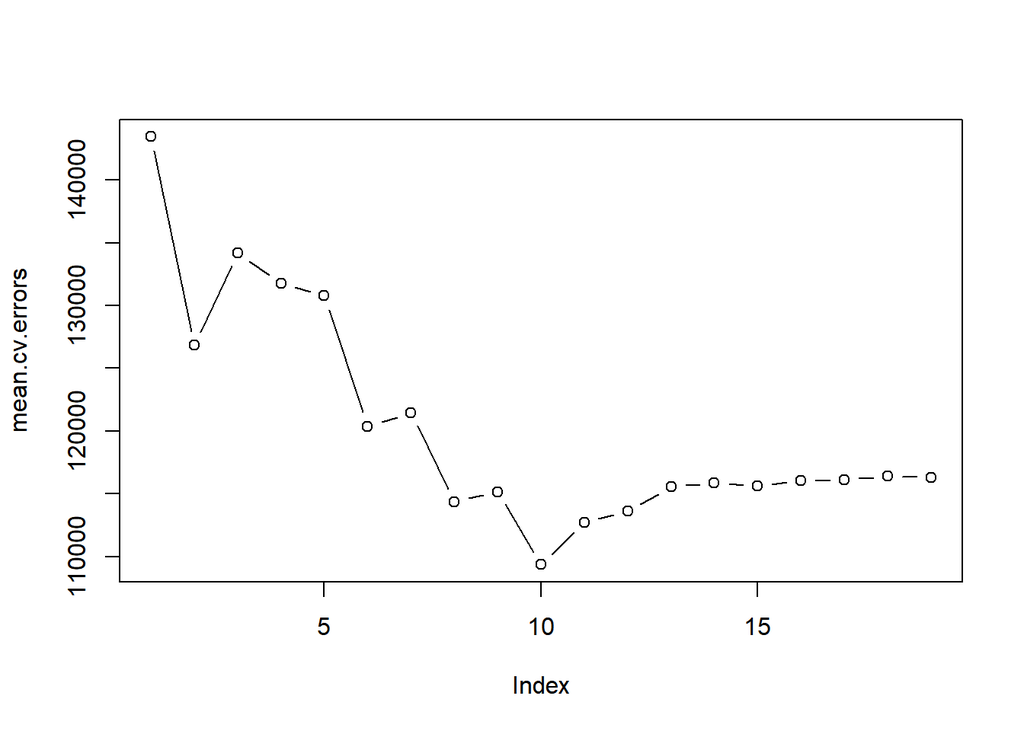

```r
par(mfrow = c(1, 1))
plot(mean.cv.errors, type = "b")
```

교차 검증은 10-변수 모형을 선택한다. 이제 전체 데이터셋에서 최상의 부분집합 선택을 수행하여 10-변수 모형형을 얻는다.

```r
reg.best <- regsubsets(Salary ~ ., data = Hitters,
    nvmax = 19)
coef(reg.best, 10)
```

```
##  (Intercept)        AtBat         Hits        Walks       CAtBat        CRuns
##  162.5354420   -2.1686501    6.9180175    5.7732246   -0.1300798    1.4082490
##         CRBI       CWalks    DivisionW      PutOuts      Assists
##    0.7743122   -0.8308264 -112.3800575    0.2973726    0.2831680
```

## 능선회귀와 라쏘

능선회귀 및 라쏘를 수행하기 위해 `glmnet` 패키지를 사용할 것이다. 이 패키지의 주요 함수는 `glmnet()`으로, 릿지 회귀 모형, 라쏘 모형 등을 적합하는 데 사용된다. 이 함수는 이 책에서 이전에 다룬 다른 모형 적합 함수들과 약간 다른 구문을 가지고 있다. 특히 `x` 행렬과 `y` 벡터를 전달해야 하며, `y ~ x` 구문은 사용하지 않는다. 이제 `Hitters` 데이터에서 Salary를 예측하기 위해 능선회귀 및 라쏘를 수행할 것이다. 진행하기 전에 앞에서처럼 누락된 값을 데이터에서 제거해야 한다.

```r
x <- model.matrix(Salary ~ ., Hitters)[, -1]
y <- Hitters$Salary
```

`model.matrix()` 함수는 `x`를 생성하는 데 유용하다. 이 함수는 $19$개의 예측 변수에 해당하는 행렬을 생성하는 뿐만 아니라 어떤 질적 변수든 자동으로 가변수로 변환한다. 후자의 특성은 `glmnet()`이 숫자형, 양적 입력만을 처리할 수 있기 때문에 중요하다.

### 능선회귀(Ridge Regression)

`glmnet()` 함수에는 어떤 유형의 모형이 적합되는지를 결정하는 `alpha` 인수가 있습니다. `alpha=0`이면 능선회귀 모형이 적합하고, `alpha=1`이면 라쏘 모형을 적합한다. 먼저 능선회귀(Ridge Regression) 모형을 적합한다.

```r
library(glmnet)
grid <- 10^seq(10, -2, length = 100)
ridge.mod <- glmnet(x, y, alpha = 0, lambda = grid)
```

기본적으로 `glmnet()` 함수는 $\lambda$ 값의 자동으로 선택된 범위에 대해 능선회귀를 수행한다. 그러나 여기서는 $\lambda=10^{10}$부터 $\lambda=10^{-2}$까지의 값 범위의 그리드에서 함수를 구현하기로 선택했다. 이는 근본적으로 절편만을 포함하는 널 모형에서부터 최소 제곱 적합까지의 모든 시나리오를 커버한다. 표준화된 변수들이 동일한 척도에 있도록 `glmnet()` 함수가 기본적으로 변수들을 표준화한다. 이 기본 설정을 해제하려면 `standardize = FALSE` 인수를 사용하면 된다.

각 $\lambda$ 값과 관련된 능선회귀 계수의 벡터가 있으며, 이는 `coef()`로 접근할 수 있는 행렬에 저장된다. 이 경우, 이는 $20 \times 100$ 행렬이며, $20$개의 행(각 예측 변수와 절편을 포함)과 $100$개의 열(각 $\lambda$ 값에 대한)이 있다.

```r
dim(coef(ridge.mod))
```

```
## [1]  20 100
```

큰 $\lambda$ 값을 사용할 때 능선회귀 계수 추정치가 $\ell_2$ 노름 측면에서 훨씬 작다. 이것들은 $\lambda=11{,}498$일 때의 계수와 그 때의 $\ell_2$ 노름이다:

```r
ridge.mod$lambda[50]
```

```
## [1] 11497.57
```

```r
coef(ridge.mod)[, 50]
```

```
##   (Intercept)         AtBat          Hits         HmRun          Runs
## 407.356050200   0.036957182   0.138180344   0.524629976   0.230701523
##           RBI         Walks         Years        CAtBat         CHits
##   0.239841459   0.289618741   1.107702929   0.003131815   0.011653637
##        CHmRun         CRuns          CRBI        CWalks       LeagueN
##   0.087545670   0.023379882   0.024138320   0.025015421   0.085028114
##     DivisionW       PutOuts       Assists        Errors    NewLeagueN
##  -6.215440973   0.016482577   0.002612988  -0.020502690   0.301433531
```

```r
sqrt(sum(coef(ridge.mod)[-1, 50]^2))
```

```
## [1] 6.360612
```

반면, $\lambda=705$일 때의 계수와 그들의 $\ell_2$ 노름은 다음과 같다. 이 작은 $\lambda$ 값과 관련된 계수의 $\ell_2$ 노름은 훨씬 크다.

```r
ridge.mod$lambda[60]
```

```
## [1] 705.4802
```

```r
coef(ridge.mod)[, 60]
```

```
##  (Intercept)        AtBat         Hits        HmRun         Runs          RBI
##  54.32519950   0.11211115   0.65622409   1.17980910   0.93769713   0.84718546
##        Walks        Years       CAtBat        CHits       CHmRun        CRuns
##   1.31987948   2.59640425   0.01083413   0.04674557   0.33777318   0.09355528
##         CRBI       CWalks      LeagueN    DivisionW      PutOuts      Assists
##   0.09780402   0.07189612  13.68370191 -54.65877750   0.11852289   0.01606037
##       Errors   NewLeagueN
##  -0.70358655   8.61181213
```

```r
sqrt(sum(coef(ridge.mod)[-1, 60]^2))
```

```
## [1] 57.11001
```

우리는 `predict()` 함수를 여러 목적으로 사용할 수 있다. 예를 들어, 새로운 $\lambda$ 값인 $50$에 대한 능선회귀 계수를 얻을 수 있다.

```r
predict(ridge.mod, s = 50, type = "coefficients")[1:20, ]
```

```
##   (Intercept)         AtBat          Hits         HmRun          Runs
##  4.876610e+01 -3.580999e-01  1.969359e+00 -1.278248e+00  1.145892e+00
##           RBI         Walks         Years        CAtBat         CHits
##  8.038292e-01  2.716186e+00 -6.218319e+00  5.447837e-03  1.064895e-01
##        CHmRun         CRuns          CRBI        CWalks       LeagueN
##  6.244860e-01  2.214985e-01  2.186914e-01 -1.500245e-01  4.592589e+01
##     DivisionW       PutOuts       Assists        Errors    NewLeagueN
## -1.182011e+02  2.502322e-01  1.215665e-01 -3.278600e+00 -9.496680e+00
```

이제 데이터를 훈련 집합과 테스트 집합으로 나누어 능선회귀 및 라쏘의 테스트 오류를 추정한다. 데이터 세트를 임의로 분할하는 두 가지 일반적인 방법이 있다. 첫 번째는 `TRUE`, `FALSE` 요소의 임의 벡터를 생성하고 `TRUE`에 해당하는 관측치를 훈련 데이터로 선택하는 것이다. 두 번째는 $1$부터 $n$까지의 수를 임의로 선택하여 이를 훈련 데이터의 인덱스로 사용하는 것이다. 두 가지 접근 방식은 동일하게 잘 작동합니다. 여기서는 후자의 접근 방식을 사용한다.

먼저 결과를 재현 가능하게 하기 위해 임의 시드를 설정한다.

```r
set.seed(1)
train <- sample(1:nrow(x), nrow(x) / 2)
test <- (-train)
y.test <- y[test]
```

다음으로 훈련 세트에서 능선회귀 모델을 적합하고 $\lambda=4$를 사용하여 테스트 집합에서 MSE를 평가한다 다시 한번 predict() 함수를 사용한다. 이번에는 `type="coefficients"`를 `newx` 인수로 대체하여 테스트 세트에 대한 예측을 얻는다.

```r
ridge.mod <- glmnet(x[train, ], y[train], alpha = 0,
    lambda = grid, thresh = 1e-12)
ridge.pred <- predict(ridge.mod, s = 4, newx = x[test, ])
mean((ridge.pred - y.test)^2)
```

```
## [1] 142199.2
```

테스트 MSE는 $142,199$입니다. 만약 절편만 있는 모형을 단순히 적합했다면 각 테스트 관측치를 훈련 관측치의 평균으로 예측했을 것이다. 그 경우 테스트 세트 MSE는 다음과 같이 계산할 수 있다.

```r
mean((mean(y[train]) - y.test)^2)
```

```
## [1] 224669.9
```

이와 같은 결과를 얻기 위해 매우 큰 $\lambda$ 값을 사용하여 릿지 회귀 모델을 적합할 수도 있다. 여기서 `1e10`은 $10^{10}$을 의미합니다.

```r
ridge.pred <- predict(ridge.mod, s = 1e10, newx = x[test, ])
mean((ridge.pred - y.test)^2)
```

```
## [1] 224669.8
```

따라서 $\lambda=4$로 능선회귀 모형을 적합하는 것이 단순히 절편만 있는 모형을 적합하는 것보다 훨씬 낮은 테스트 MSE를 가지게 된다. 이제 $\lambda=4$로 능선회귀를 수행하는 것과 최소 제곱 회귀를 수행하는 것 사이에 어떤 이익이 있는지 확인해 볼 것이다. 최소 제곱은 단순히 $\lambda=0$인 능선회귀이다. (`glmnet()`이 $\lambda=0$일 때 정확한 최소 제곱 계수를 생성하려면 `predict()` 함수를 호출할 때 `exact = T` 인수를 사용한다. 그렇지 않으면 `predict()` 함수는 `glmnet()` 모델 적합에 사용된 $\lambda$ 값 그리드를 보간하여 근사 결과를 생성한다. `exact = T`를 사용하더라도 `glmnet()`의 출력과 `lm()`의 출력 사이에 세 번째 소수 자리에서 약간의 차이가 있다. 이것은 `glmnet()`의 수치 근사로 인한 것이다.)

```r
ridge.pred <- predict(ridge.mod, s = 0, newx = x[test, ],
    exact = T, x = x[train, ], y = y[train])
mean((ridge.pred - y.test)^2)
```

```
## [1] 168588.6
```

```r
lm(y ~ x, subset = train)
```

```
##
## Call:
## lm(formula = y ~ x, subset = train)
##
## Coefficients:
## (Intercept)       xAtBat        xHits       xHmRun        xRuns         xRBI
##    274.0145      -0.3521      -1.6377       5.8145       1.5424       1.1243
##      xWalks       xYears      xCAtBat       xCHits      xCHmRun       xCRuns
##      3.7287     -16.3773      -0.6412       3.1632       3.4008      -0.9739
##       xCRBI      xCWalks     xLeagueN   xDivisionW     xPutOuts     xAssists
##     -0.6005       0.3379     119.1486    -144.0831       0.1976       0.6804
##     xErrors  xNewLeagueN
##     -4.7128     -71.0951
```

```r
predict(ridge.mod, s = 0, exact = T, type = "coefficients",
    x = x[train, ], y = y[train])[1:20, ]
```

```
##  (Intercept)        AtBat         Hits        HmRun         Runs          RBI
##  274.0200994   -0.3521900   -1.6371383    5.8146692    1.5423361    1.1241837
##        Walks        Years       CAtBat        CHits       CHmRun        CRuns
##    3.7288406  -16.3795195   -0.6411235    3.1629444    3.4005281   -0.9739405
##         CRBI       CWalks      LeagueN    DivisionW      PutOuts      Assists
##   -0.6003976    0.3378422  119.1434637 -144.0853061    0.1976300    0.6804200
##       Errors   NewLeagueN
##   -4.7127879  -71.0898914
```

일반적으로 (정규화가 안된) 최소 제곱 모델을 적합하려면 더 유용한 출력(계수의 표준 오차 및 p-값과 같은)을 제공하는 `lm()` 함수를 사용해야 한다.

일반적으로 $\lambda=4$를 임의로 선택하는 대신 교차 검증을 사용하여 조정 매개변수 $\lambda$를 선택하는 것이 더 좋다. 내장된 교차 검증 함수 `cv.glmnet()`을 사용하여 이를 수행할 수 있습니다. 기본적으로 이 함수는 10겹 교차 검증을 수행하지만 `nfolds` 인수를 사용하여 변경할 수 있다. 교차 검증 폴드의 선택이 임의적이므로 결과를 재현 가능하게 하기 위해 먼저 임의 시드를 설정한다.

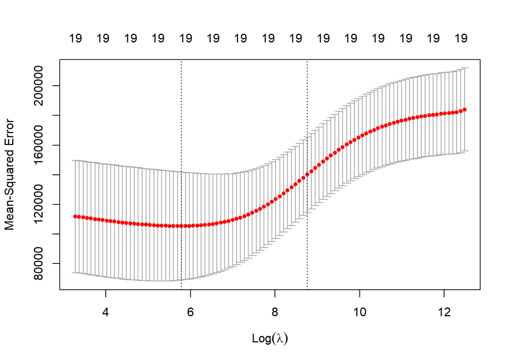

```r
set.seed(1)
cv.out <- cv.glmnet(x[train, ], y[train], alpha = 0)
plot(cv.out)
```

```r
bestlam <- cv.out$lambda.min
bestlam
```

```
## [1] 326.0828
```

따라서 최소 교차 검증 오류를 나타내는 $\lambda$ 값은 $326$이다. 이 $\lambda$ 값과 관련된 테스트 MSE는 다음과 같이 계산할 수 있다.

```r
ridge.pred <- predict(ridge.mod, s = bestlam,
    newx = x[test, ])
mean((ridge.pred - y.test)^2)
```

```
## [1] 139856.6
```

이는 $\lambda=4$를 사용한 테스트 MSE에 비해 더 큰 개선을 나타냅니다. 마지막으로, 교차 검증으로 선택된 $\lambda$ 값으로 전체 데이터셋에 대해 다시 능선 회귀 모형을 적합하고 계수 추정치를 조사한다.

```r
out <- glmnet(x, y, alpha = 0)
predict(out, type = "coefficients", s = bestlam)[1:20, ]
```

```
##  (Intercept)        AtBat         Hits        HmRun         Runs          RBI
##  15.44383120   0.07715547   0.85911582   0.60103106   1.06369007   0.87936105
##        Walks        Years       CAtBat        CHits       CHmRun        CRuns
##   1.62444617   1.35254778   0.01134999   0.05746654   0.40680157   0.11456224
##         CRBI       CWalks      LeagueN    DivisionW      PutOuts      Assists
##   0.12116504   0.05299202  22.09143197 -79.04032656   0.16619903   0.02941950
##       Errors   NewLeagueN
##  -1.36092945   9.12487765
```

예상대로, 모든 계수가 0이 아니다—릿지 회귀는 변수 선택을 수행하지 않는다.

### 라쏘(Lasso)

`Hitters` 데이터셋에서 적절한 $\lambda$ 선택으로 능선회귀가 최소 제곱 및 널 모형보다 더 나은 성능을 보였다. 이제 라쏘가 릿지 회귀보다 더 정확하거나 더 해석 가능한 모형을 생성할 수 있는지 확인하고자 하낟. 라쏘 모형을 적합하기 위해 다시 한 번 `glmnet()` 함수를 사용하지만, 이번에는 `alpha=1` 인수를 사용한다. 이 외에는 능선회귀와 같다.

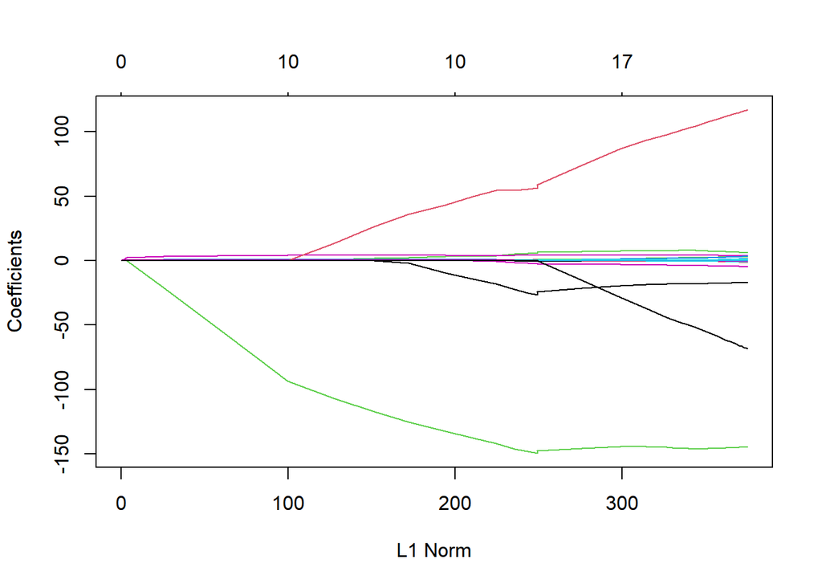

```r
lasso.mod <- glmnet(x[train, ], y[train], alpha = 1,
    lambda = grid)
plot(lasso.mod)
```

계수 그래프에서 튜닝 매개변수 선택에 따라 일부 계수가 정확히 0이 될 수 있음을 확인할 수 있다. 이제 교차 검증을 수행하고 관련된 테스트 오류를 계산한다.

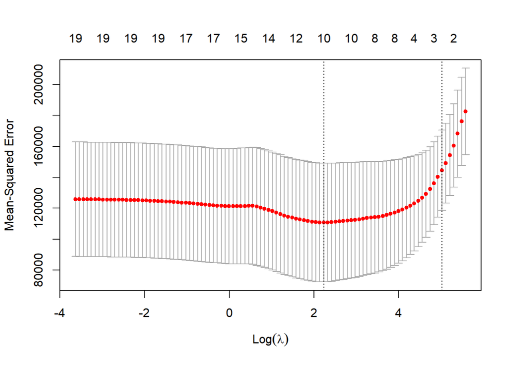

```r
set.seed(1)
cv.out <- cv.glmnet(x[train, ], y[train], alpha = 1)
plot(cv.out)
```

```r
bestlam <- cv.out$lambda.min
lasso.pred <- predict(lasso.mod, s = bestlam,
    newx = x[test, ])
mean((lasso.pred - y.test)^2)
```

```
## [1] 143673.6
```

이는 널 모형과 최소 제곱의 테스트 세트 MSE보다 상당히 낮으며, 교차 검증을 통해 선택된 $\lambda$로 능선회귀의 테스트 MSE와 매우 유사합니다.

그러나 라쏘는 결과적으로 계수 추정이 희소(sparse)하게 된다는 면에서 능선회귀에 비해 상당한 장점이 있다. 여기서 19개의 계수 추정치 중 8개가 정확히 0임을 확인할 수 있다. 따라서 교차 검증을 통해 선택된 $\lambda$ 값을 사용했을 때 라쏘 모델은 11개 변수만 포함한다.

```r
out <- glmnet(x, y, alpha = 1, lambda = grid)
lasso.coef <- predict(out, type = "coefficients",
    s = bestlam)[1:20, ]
lasso.coef
```

```
##   (Intercept)         AtBat          Hits         HmRun          Runs
##    1.27479059   -0.05497143    2.18034583    0.00000000    0.00000000
##           RBI         Walks         Years        CAtBat         CHits
##    0.00000000    2.29192406   -0.33806109    0.00000000    0.00000000
##        CHmRun         CRuns          CRBI        CWalks       LeagueN
##    0.02825013    0.21628385    0.41712537    0.00000000   20.28615023
##     DivisionW       PutOuts       Assists        Errors    NewLeagueN
## -116.16755870    0.23752385    0.00000000   -0.85629148    0.00000000
```

```r
lasso.coef[lasso.coef != 0]
```

```
##   (Intercept)         AtBat          Hits         Walks         Years
##    1.27479059   -0.05497143    2.18034583    2.29192406   -0.33806109
##        CHmRun         CRuns          CRBI       LeagueN     DivisionW
##    0.02825013    0.21628385    0.41712537   20.28615023 -116.16755870
##       PutOuts        Errors
##    0.23752385   -0.85629148
```

# 다항회귀, 비모수회귀, 일반화 가법모형

이 실습에서는 이 장에서 다룬 복잡한 비선형 적합 절차 중 많은 것들이 R에서 쉽게 구현될 수 있음을 보여주기 위해 예제에서 사용된 Wage 데이터를 다시 분석한다. 먼저 데이터를 포함하는 `ISLR2` 라이브러리를 로드한다.

```r
library(ISLR2)
attach(Wage)
```

## 다항회귀모형(Polynomial Regression)

다음 명령을 사용하여 다항회귀모형을 적합한다.

```r
fit <- lm(wage ~ poly(age, 4), data = Wage)
coef(summary(fit))
```

```
##                 Estimate Std. Error    t value     Pr(>|t|)
## (Intercept)    111.70361  0.7287409 153.283015 0.000000e+00
## poly(age, 4)1  447.06785 39.9147851  11.200558 1.484604e-28
## poly(age, 4)2 -478.31581 39.9147851 -11.983424 2.355831e-32
## poly(age, 4)3  125.52169 39.9147851   3.144742 1.678622e-03
## poly(age, 4)4  -77.91118 39.9147851  -1.951938 5.103865e-02
```

이 구문은 `lm()` 함수를 사용하여 `age`의 4차 다항식을 사용하여 `wage`를 예측하는 선형 모형을 적합한다: `poly(age, 4)`. `poly()` 명령을 사용하면 `age`의 제곱, 세제곱 및 네제곱 등 긴 공식을 작성할 필요가 없다. 이 함수는 *직교 다항식*의 기저를 반환하는데, 이는 각 열이 변수 `age`, `age^2`, `age^3` 및 `age^4`의 선형 조합임을 의미합니다.

그러나 `raw = TRUE` 인수를 poly() 함수에 사용하면 직접 `age`, `age^2`, `age^3` 및 `age^4`를 얻는다. 어떤 것을 선택하든 모형에 의미있는 영향은 주지 않는다. 기저의 선택은 계수 추정치를 다르게 하지만 적합된 값에는 영향을 미치지 않는다.

```r
fit2 <- lm(wage ~ poly(age, 4, raw = T), data = Wage)
coef(summary(fit2))
```

```
##                             Estimate   Std. Error   t value     Pr(>|t|)
## (Intercept)            -1.841542e+02 6.004038e+01 -3.067172 0.0021802539
## poly(age, 4, raw = T)1  2.124552e+01 5.886748e+00  3.609042 0.0003123618
## poly(age, 4, raw = T)2 -5.638593e-01 2.061083e-01 -2.735743 0.0062606446
## poly(age, 4, raw = T)3  6.810688e-03 3.065931e-03  2.221409 0.0263977518
## poly(age, 4, raw = T)4 -3.203830e-05 1.641359e-05 -1.951938 0.0510386498
```

이 모형을 적합하는 다른 동등한 방법이 여러 가지 있으며, 이는 `R`의 유연성을 보여준다.

```r
fit2a <- lm(wage ~ age + I(age^2) + I(age^3) + I(age^4),
    data = Wage)
coef(fit2a)
```

```
##   (Intercept)           age      I(age^2)      I(age^3)      I(age^4)
## -1.841542e+02  2.124552e+01 -5.638593e-01  6.810688e-03 -3.203830e-05
```

이 코드는 `age^2`와 같은 항을 *wrapper* 함수 `I()`를 통해 만들면서 다항식 기저 함수를 생성합니다. (수식에서 `^` 기호는 특수한 의미를 가집니다).

```r
fit2b <- lm(wage ~ cbind(age, age^2, age^3, age^4),
    data = Wage)
```

이 코드는 `cbind()` 함수를 이용하여 같은 작업을 좀 더 간략하게 나타낸다. `cbind()` 같은 함수도 *wrapper* 함수로 작동한다.

이제 `age`에 대한 예측값을 원하는 `age` 값의 그리드에 대해 생성하고, 표준 오차를 함께 얻기 위해 일반적인 `predict()` 함수를 호출한다.

```r
agelims <- range(age)
age.grid <- seq(from = agelims[1], to = agelims[2])
preds <- predict(fit, newdata = list(age = age.grid),
    se = TRUE)
se.bands <- cbind(preds$fit + 2 * preds$se.fit,
    preds$fit - 2 * preds$se.fit)
```

마지막으로, 자료와 4차 다항식 적합값을 플롯한다. Finally, we plot the data and add the fit from the degree-4 polynomial.

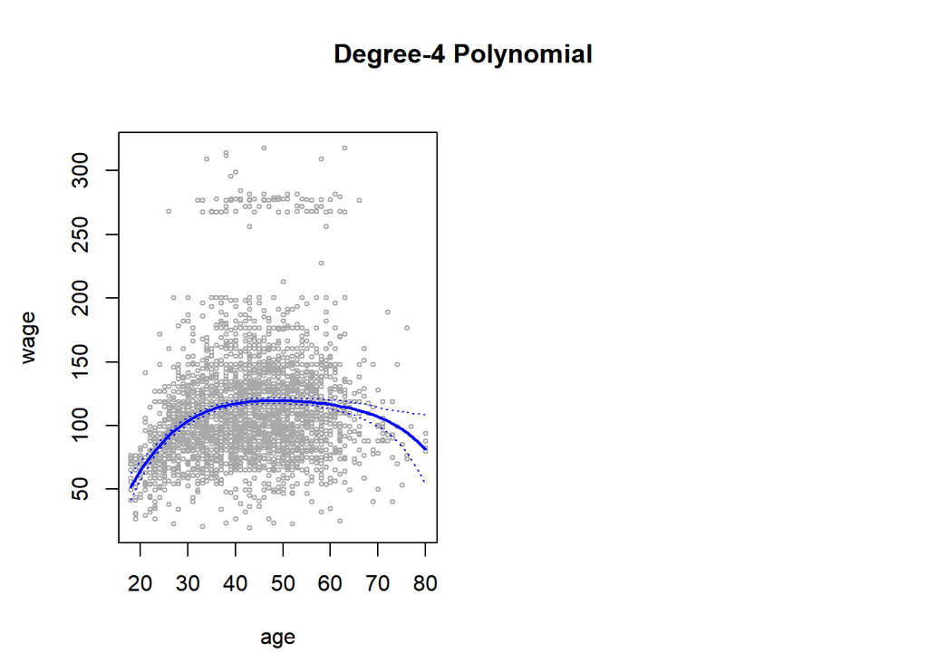

```r
par(mfrow = c(1, 2), mar = c(4.5, 4.5, 1, 1),
    oma = c(0, 0, 4, 0))
plot(age, wage, xlim = agelims, cex = .5, col = "darkgrey")
title("Degree-4 Polynomial", outer = T)
lines(age.grid, preds$fit, lwd = 2, col = "blue")
matlines(age.grid, se.bands, lwd = 1, col = "blue", lty = 3)
```

이전에 언급한 바와 같이 `poly()` 함수에서 직교 세트의 기저 함수가 생성되는지 여부는 얻은 모형에 영향을 미치지 않는데, 둘의 적합값은 동일하다.

```r
preds2 <- predict(fit2, newdata = list(age = age.grid),
    se = TRUE)
max(abs(preds$fit - preds2$fit))
```

```
## [1] 6.842527e-11
```

## 계단함수를 이용한 회귀모형(Step Functions)

계단 함수를 적합하기 위해 `cut()` 함수를 사용합니다.

```r
table(cut(age, 4))
```

```
##
## (17.9,33.5]   (33.5,49]   (49,64.5] (64.5,80.1]
##         750        1399         779          72
```

```r
fit <- lm(wage ~ cut(age, 4), data = Wage)
coef(summary(fit))
```

```
##                         Estimate Std. Error   t value     Pr(>|t|)
## (Intercept)            94.158392   1.476069 63.789970 0.000000e+00
## cut(age, 4)(33.5,49]   24.053491   1.829431 13.148074 1.982315e-38
## cut(age, 4)(49,64.5]   23.664559   2.067958 11.443444 1.040750e-29
## cut(age, 4)(64.5,80.1]  7.640592   4.987424  1.531972 1.256350e-01
```

여기서 `cut()`은 자동으로 $33.5$, $49$, $64.5$ 세의 절점을 선택했다. `breaks` 옵션을 사용하여 직접 자르기점을 지정할 수도 있다. 함수 `cut()`은 순서가 지정된 범주형 변수를 반환하며, `lm()` 함수는 회귀 분석에 사용할 가변수 집합을 생성합니다. `age < 33.5` 범주는 제외되므로, $94{,}160$의 절편 계수는 $33.5$세 미만인 사람들의 평균 급여로 해석될 수 있으며, 다른 계수는 다른 연령 그룹에 속한 사람들의 평균 추가 급여로 해석될 수 있다. 다항식 적합의 경우와 마찬가지로 예측 및 플롯을 생성할 수 있다.

## 회귀 스플라인(regression spline)

R에서 회귀 스플라인을 적합하려면 `splines` 라이브러리를 사용한다. `bs()` 함수는 지정된 절점을 가진 스플라인의 전체 기저 함수 행렬을 생성한다. 기본적으로 3차 스플라인이 생성된다. 아래와 같이 회귀 스플라인을 사용하여 `age`에 대한 `wage`를 적합한다.

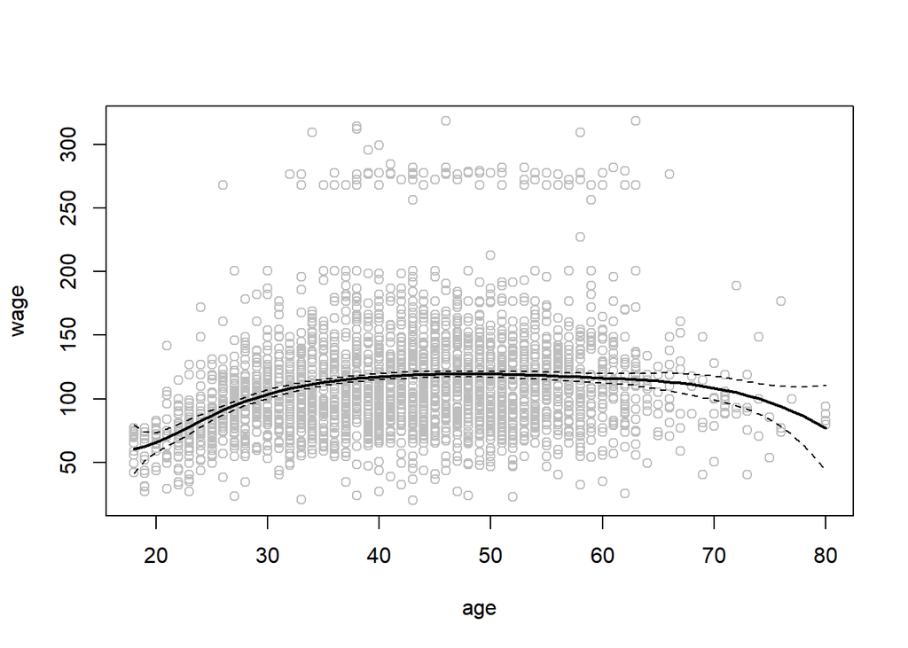

```r
library(splines)
fit <- lm(wage ~ bs(age, knots = c(25, 40, 60)), data = Wage)
pred <- predict(fit, newdata = list(age = age.grid), se = T)
plot(age, wage, col = "gray")
lines(age.grid, pred$fit, lwd = 2)
lines(age.grid, pred$fit + 2 * pred$se, lty = "dashed")
lines(age.grid, pred$fit - 2 * pred$se, lty = "dashed")
```

여기서는 나이 $25$, $40$, $60$에서 미리 지정된 절점이 있다. 이것은 여섯 개의 기저 함수를 가진 스플라인을 생성한다. (세 절점을 가진 3차 스플라인은 일곱 자유도를 가지고 있다; 이 자유도는 절편에 사용되며, 여섯 개의 기저 함수를 사용한다.) 우리는 또한 데이터의 균일 분위수에서 절점을 가지는 스플라인을 생성하기 위해 `df` 옵션을 사용할 수 있다.

```r
dim(bs(age, knots = c(25, 40, 60)))
```

```
## [1] 3000    6
```

```r
dim(bs(age, df = 6))
```

```
## [1] 3000    6
```

```r
attr(bs(age, df = 6), "knots")
```

```
## [1] 33.75 42.00 51.00
```

이 경우 `R`은 데이터의 25th, 50th 및 75th 백분위수에 해당하는 $33.8, 42.0$, 및 $51.0$ 세의 나이에서 절점을 선택한다. `bs()` 함수에는 `degree` 인수도 있으므로, 기본적으로 3차 스플라인을 생성하는 대신 어떤 차수의 스플라인을 적합할 수 있다.

## 자연 스플라인(natural spline)

자연 스플라인을 적합하기 위해 ns() 함수를 사용한다. 여기서 우리는 자유도가 4개인 자연 스플라인을 적합한다.

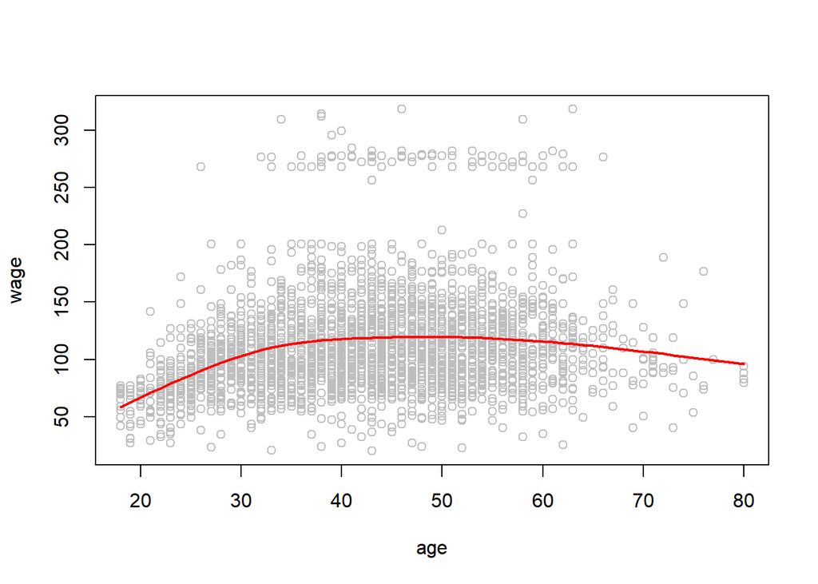

```r
fit2 <- lm(wage ~ ns(age, df = 4), data = Wage)
pred2 <- predict(fit2, newdata = list(age = age.grid),
     se = T)
plot(age, wage, col = "gray")
lines(age.grid, pred2$fit, col = "red", lwd = 2)
```

`bs()` 함수와 마찬가지로 `knots` 옵션을 사용하여 직접 절점을 지정할 수도 있다.

## 평활 스플라인(smoothing splines)

평활 스플라인을 적합하기 위해 `smooth.spline()` 함수를 사용한다.

```r
plot(age, wage, xlim = agelims, cex = .5, col = "darkgrey")
title("Smoothing Spline")
fit <- smooth.spline(age, wage, df = 16)
fit2 <- smooth.spline(age, wage, cv = TRUE)
fit2$df
```

```
## [1] 6.794596
```

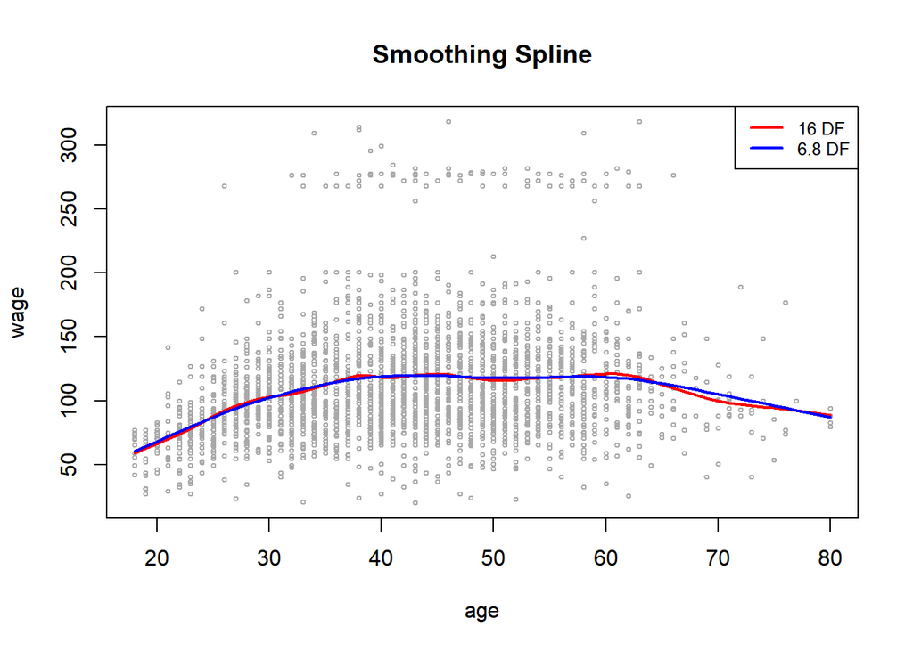

```r
lines(fit, col = "red", lwd = 2)
lines(fit2, col = "blue", lwd = 2)
legend("topright", legend = c("16 DF", "6.8 DF"),
    col = c("red", "blue"), lty = 1, lwd = 2, cex = .8)
```

첫 번째 `smooth.spline()` 호출에서 `df = 16`을 지정했다. 함수는 자유도가 16개인 $\lambda$ 값이 되도록 결정한다. 두 번째 `smooth.spline()` 호출에서는 교차 검증을 통해 부드러운 정도를 선택한다. 이로써 자유도가 6.8개인 $\lambda$ 값을 얻는다.

## 국소 회귀모형(local regression)

국소 회귀를 수행하기 위해 `loess()` 함수를 사용합니다.

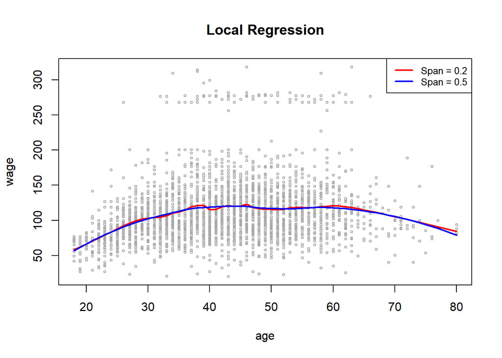

```r
plot(age, wage, xlim = agelims, cex = .5, col = "darkgrey")
title("Local Regression")
fit <- loess(wage ~ age, span = .2, data = Wage)
fit2 <- loess(wage ~ age, span = .5, data = Wage)
lines(age.grid, predict(fit, data.frame(age = age.grid)),
    col = "red", lwd = 2)
lines(age.grid, predict(fit2, data.frame(age = age.grid)),
    col = "blue", lwd = 2)
legend("topright", legend = c("Span = 0.2", "Span = 0.5"),
    col = c("red", "blue"), lty = 1, lwd = 2, cex = .8)
```

여기서 우리는 $0.2$ 및 $0.5$의 스패닝을 사용하여 국소 선형 회귀를 수행했다. 즉, 각 이웃은 관측치의 20% 또는 50%를 포함한다. 스패닝이 클수록 적합이 부드러워진다. `R`에서 국소 회귀 모형을 적합하는 데에는 `locfit` 라이브러리도 사용할 수 있다.

## 일반화 가법모형(generalized additive models)

이제 `lyear`와 `age`의 자연 스플라인 함수를 사용하여 `education`을 질적 예측 변수로 사용하여 `wage`를 예측하는 GAM을 적합합니다. 이는 적절한 기저 함수 선택을 사용한 큰 선형 회귀 모형일 뿐이므로, lm() 함수를 사용하여 간단히 수행할 수 있다.

```r
gam1 <- lm(wage ~ ns(year, 4) + ns(age, 5) + education,
    data = Wage)
```

이제 위의 모형을 자연 스플라인 대신 평활 스플라인을 사용하여 적합한다. 기저 함수로 표현할 수 없는 평활 스플라인이나 다른 구성 요소를 사용하여 보다 일반적인 종류의 GAM을 적합하기 위해서는 `R`의 `gam` 라이브러리를 사용해야 한다.

`s()` 함수는 `gam` 라이브러리의 일부이며, 평활 스플라인을 사용하려는 것을 나타낸다. `lyear` 함수의 자유도를 $4$로, age 함수의 자유도를 $5$로 지정한다. `education`이 질적이므로 그대로 둔 채, 네 개의 가변수로 변환된다. `gam()` 함수를 사용하여 이러한 구성 요소를 사용하여 GAM을 적합한다.

```r
library(gam)
gam.m3 <- gam(wage ~ s(year, 4) + s(age, 5) + education,
    data = Wage)
```

그러고 나서 `plot()` 함수를 불러온다.

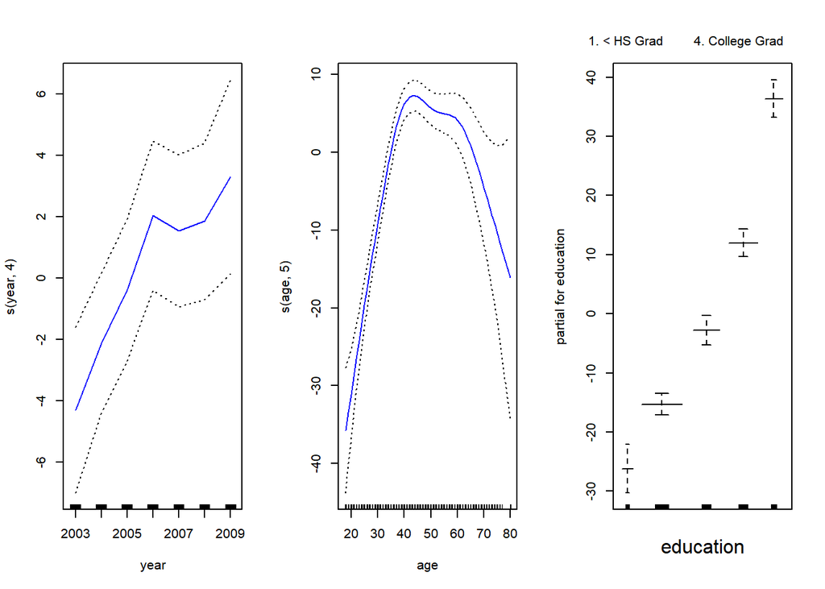

```r
par(mfrow = c(1, 3))
plot(gam.m3, se = TRUE, col = "blue")
```

일반적인 `plot()` 함수는 `gam.m3`가 `Gam` 클래스의 객체임을 인식하고 적절한 `plot.Gam()` 메서드를 호출한다. 편리하게도, `gam1`이 `Gam` 클래스가 아니라 `lm` 클래스임에도 불구하고 우리는 여전히 그 위에 `plot.Gam()`을 사용할 수 있다.

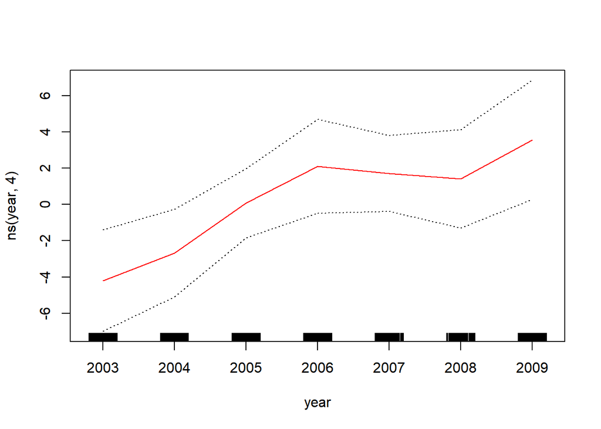

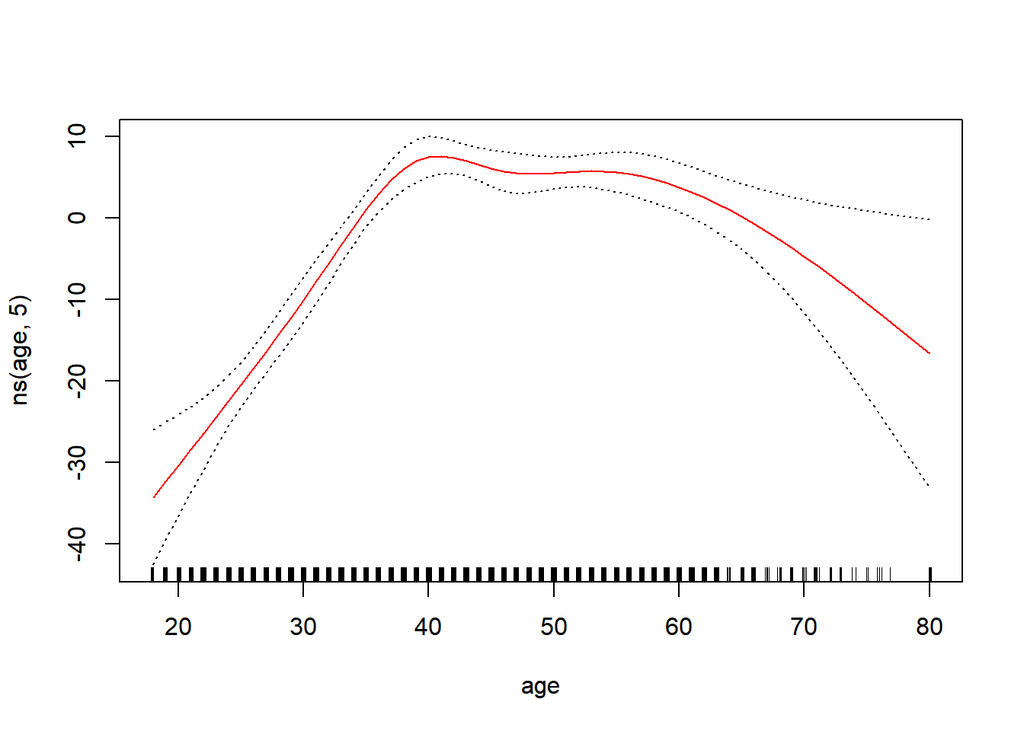

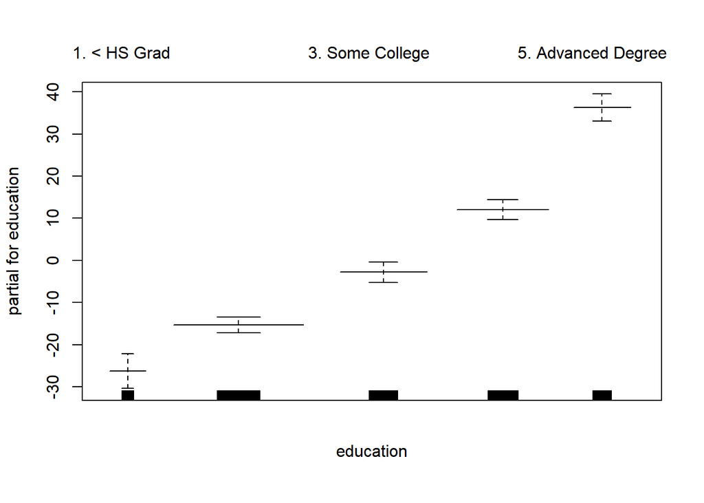

```r
plot.Gam(gam1, se = TRUE, col = "red")
```

여기서 일반적인 `plot()` 함수 대신 `plot.Gam()`을 사용했다.

summary() 함수는 gam 적합의 요약을 생성합니다.

The `summary()` function produces a summary of the gam fit.

```r
summary(gam.m3)
```

```
##
## Call: gam(formula = wage ~ s(year, 4) + s(age, 5) + education, data = Wage)
## Deviance Residuals:
##     Min      1Q  Median      3Q     Max
## -119.43  -19.70   -3.33   14.17  213.48
##
## (Dispersion Parameter for gaussian family taken to be 1235.69)
##
##     Null Deviance: 5222086 on 2999 degrees of freedom
## Residual Deviance: 3689770 on 2986 degrees of freedom
## AIC: 29887.75
##
## Number of Local Scoring Iterations: NA
##
## Anova for Parametric Effects
##              Df  Sum Sq Mean Sq F value    Pr(>F)
## s(year, 4)    1   27162   27162  21.981 2.877e-06 ***
## s(age, 5)     1  195338  195338 158.081 < 2.2e-16 ***
## education     4 1069726  267432 216.423 < 2.2e-16 ***
## Residuals  2986 3689770    1236
## ---
## Signif. codes:  0 '***' 0.001 '**' 0.01 '*' 0.05 '.' 0.1 ' ' 1
##
## Anova for Nonparametric Effects
##             Npar Df Npar F  Pr(F)
## (Intercept)
## s(year, 4)        3  1.086 0.3537
## s(age, 5)         4 32.380 <2e-16 ***
## education
## ---
## Signif. codes:  0 '***' 0.001 '**' 0.01 '*' 0.05 '.' 0.1 ' ' 1
```

“Parametric Effects에 대한 Anova” p-값은 year, age, 그리고 education이 모두 선형 관계만을 가정할 때에도 매우 통계적으로 유의미하다는 것을 명백히 보여준다. 반면에, year와 age에 대한 “비모수적 효과에 대한 Anova” p-값은 선형 관계 대비 비선형 관계의 귀무 가설을 나타낸다. year에 대한 큰 p-값은 ANOVA 테스트에서 우리의 결론을 강화한다. 그러나 `age`에 대한 비선형 항이 필요하다는 매우 명백한 증거가 있습니다.